# Populated PAP

### Hypothesis 4b

```r
H4b_cov <- lm_robust(ft_rep_post ~ condition_dummy * factor(party_numeric)
                     + condition_dummy * PID_strength
                     + condition_dummy * social_closeness
                     + condition_dummy * ft_rep_pre
                     + ideology_selfreport
                     + maga
                     + ft_dem_pre,
                     data = data_clean, se_type = "HC2")
```

| term | estimate | std.error | statistic | p.value | conf.low | conf.high | df | outcome |
| --- | --- | --- | --- | --- | --- | --- | --- | --- |
| (Intercept) | -3.103 | 1.836 | -1.690 | 0.091 | -6.707 | 0.502 | 758 | ft_rep_post |
| condition_dummy | 2.754 | 2.807 | 0.981 | 0.327 | -2.756 | 8.264 | 758 | ft_rep_post |
| factor(party_numeric)2 | -0.088 | 0.881 | -0.100 | 0.921 | -1.817 | 1.641 | 758 | ft_rep_post |
| factor(party_numeric)3 | 2.603 | 1.688 | 1.542 | 0.124 | -0.711 | 5.916 | 758 | ft_rep_post |
| factor(party_numeric)5 | 0.983 | 2.131 | 0.461 | 0.645 | -3.200 | 5.166 | 758 | ft_rep_post |
| factor(party_numeric)6 | 3.932 | 2.035 | 1.932 | 0.054 | -0.064 | 7.927 | 758 | ft_rep_post |
| factor(party_numeric)7 | 4.429 | 2.455 | 1.804 | 0.072 | -0.390 | 9.247 | 758 | ft_rep_post |
| PID_strength | 0.653 | 0.408 | 1.600 | 0.110 | -0.148 | 1.455 | 758 | ft_rep_post |
| social_closeness | 1.300 | 0.491 | 2.649 | 0.008 | 0.337 | 2.264 | 758 | ft_rep_post |
| ft_rep_pre | 0.914 | 0.026 | 34.999 | 0.000 | 0.863 | 0.966 | 758 | ft_rep_post |
| ideology_selfreport | 0.048 | 0.337 | 0.142 | 0.887 | -0.614 | 0.710 | 758 | ft_rep_post |
| maga | 0.814 | 0.816 | 0.998 | 0.318 | -0.787 | 2.416 | 758 | ft_rep_post |
| ft_dem_pre | -0.015 | 0.013 | -1.145 | 0.253 | -0.041 | 0.011 | 758 | ft_rep_post |
| condition_dummy:factor(party_numeric)2 | 0.611 | 1.348 | 0.453 | 0.650 | -2.034 | 3.256 | 758 | ft_rep_post |
| condition_dummy:factor(party_numeric)3 | -2.818 | 2.182 | -1.292 | 0.197 | -7.102 | 1.465 | 758 | ft_rep_post |
| condition_dummy:factor(party_numeric)5 | -0.909 | 3.958 | -0.230 | 0.818 | -8.679 | 6.861 | 758 | ft_rep_post |
| condition_dummy:factor(party_numeric)6 | 0.287 | 2.567 | 0.112 | 0.911 | -4.752 | 5.327 | 758 | ft_rep_post |
| condition_dummy:factor(party_numeric)7 | 3.883 | 3.253 | 1.194 | 0.233 | -2.503 | 10.269 | 758 | ft_rep_post |
| condition_dummy:PID_strength | -0.630 | 0.652 | -0.966 | 0.334 | -1.911 | 0.650 | 758 | ft_rep_post |
| condition_dummy:social_closeness | -0.862 | 0.603 | -1.429 | 0.153 | -2.045 | 0.322 | 758 | ft_rep_post |
| condition_dummy:ft_rep_pre | -0.024 | 0.039 | -0.625 | 0.532 | -0.100 | 0.052 | 758 | ft_rep_post |

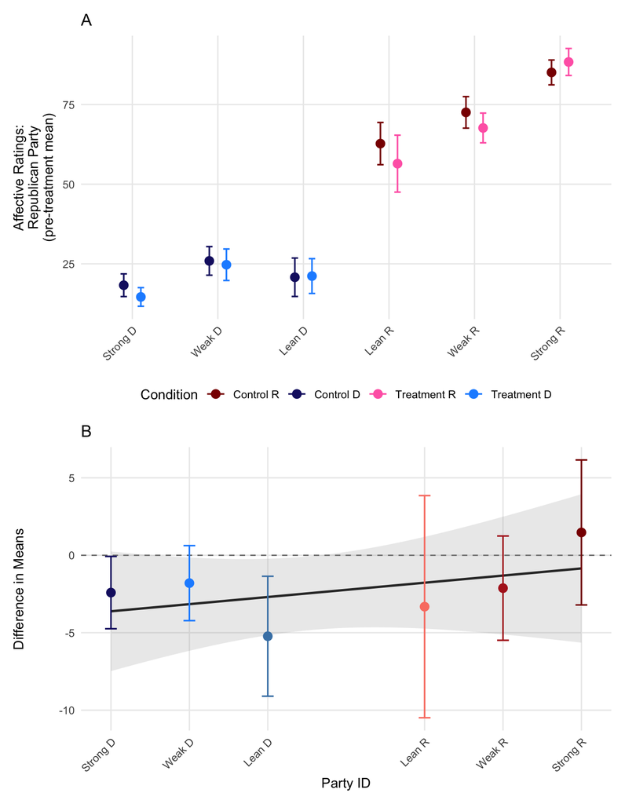

### Hypothesis 5

```r
H5_cov <- lm_robust(ft_rep_post ~ condition_dummy * factor(party_numeric) * PID_bin
                    + condition_dummy * social_closeness
                    + condition_dummy * ft_rep_pre
                    + condition_dummy * ft_dem_pre
                    + ideology_selfreport
                    + maga,
                    data = data_clean, se_type = "HC2")
```

| term | estimate | std.error | statistic | p.value | conf.low | conf.high | df | outcome |
| --- | --- | --- | --- | --- | --- | --- | --- | --- |
| (Intercept) | -1.838 | 1.344 | -1.367 | 0.172 | -4.476 | 0.801 | 747 | ft_rep_post |
| condition_dummy | 1.727 | 2.557 | 0.675 | 0.500 | -3.293 | 6.748 | 747 | ft_rep_post |
| factor(party_numeric)2 | -1.567 | 2.015 | -0.777 | 0.437 | -5.524 | 2.390 | 747 | ft_rep_post |
| factor(party_numeric)3 | -1.434 | 1.794 | -0.799 | 0.424 | -4.957 | 2.088 | 747 | ft_rep_post |
| factor(party_numeric)5 | 0.152 | 2.400 | 0.063 | 0.949 | -4.559 | 4.863 | 747 | ft_rep_post |
| factor(party_numeric)6 | 1.400 | 2.068 | 0.677 | 0.498 | -2.659 | 5.460 | 747 | ft_rep_post |
| factor(party_numeric)7 | 3.231 | 3.042 | 1.062 | 0.288 | -2.740 | 9.203 | 747 | ft_rep_post |
| PID_bin | 0.628 | 0.561 | 1.119 | 0.263 | -0.473 | 1.728 | 747 | ft_rep_post |
| social_closeness | 1.508 | 0.465 | 3.245 | 0.001 | 0.596 | 2.421 | 747 | ft_rep_post |
| ft_rep_pre | 0.914 | 0.028 | 33.168 | 0.000 | 0.860 | 0.968 | 747 | ft_rep_post |
| ft_dem_pre | -0.021 | 0.017 | -1.295 | 0.196 | -0.054 | 0.011 | 747 | ft_rep_post |
| ideology_selfreport | 0.052 | 0.333 | 0.156 | 0.876 | -0.601 | 0.705 | 747 | ft_rep_post |
| maga | 0.694 | 0.809 | 0.858 | 0.391 | -0.895 | 2.283 | 747 | ft_rep_post |
| condition_dummy:factor(party_numeric)2 | -0.214 | 3.221 | -0.066 | 0.947 | -6.537 | 6.110 | 747 | ft_rep_post |
| condition_dummy:factor(party_numeric)3 | 2.070 | 2.983 | 0.694 | 0.488 | -3.786 | 7.925 | 747 | ft_rep_post |
| condition_dummy:factor(party_numeric)5 | 3.740 | 5.881 | 0.636 | 0.525 | -7.804 | 15.285 | 747 | ft_rep_post |
| condition_dummy:factor(party_numeric)6 | -1.926 | 4.010 | -0.480 | 0.631 | -9.799 | 5.947 | 747 | ft_rep_post |
| condition_dummy:factor(party_numeric)7 | 3.134 | 4.923 | 0.637 | 0.525 | -6.531 | 12.799 | 747 | ft_rep_post |
| condition_dummy:PID_bin | -0.740 | 1.225 | -0.604 | 0.546 | -3.145 | 1.664 | 747 | ft_rep_post |
| factor(party_numeric)2:PID_bin | 0.705 | 1.363 | 0.517 | 0.605 | -1.971 | 3.380 | 747 | ft_rep_post |
| factor(party_numeric)3:PID_bin | 4.340 | 3.001 | 1.446 | 0.149 | -1.552 | 10.232 | 747 | ft_rep_post |
| factor(party_numeric)5:PID_bin | 0.063 | 1.736 | 0.036 | 0.971 | -3.345 | 3.471 | 747 | ft_rep_post |
| factor(party_numeric)6:PID_bin | 1.251 | 1.466 | 0.854 | 0.394 | -1.626 | 4.129 | 747 | ft_rep_post |
| factor(party_numeric)7:PID_bin | 0.556 | 1.686 | 0.330 | 0.742 | -2.753 | 3.866 | 747 | ft_rep_post |
| condition_dummy:social_closeness | -1.073 | 0.604 | -1.776 | 0.076 | -2.259 | 0.113 | 747 | ft_rep_post |
| condition_dummy:ft_rep_pre | -0.024 | 0.040 | -0.592 | 0.554 | -0.103 | 0.055 | 747 | ft_rep_post |
| condition_dummy:ft_dem_pre | 0.007 | 0.028 | 0.251 | 0.802 | -0.048 | 0.062 | 747 | ft_rep_post |
| condition_dummy:factor(party_numeric)2:PID_bin | 0.851 | 2.049 | 0.415 | 0.678 | -3.171 | 4.873 | 747 | ft_rep_post |
| condition_dummy:factor(party_numeric)3:PID_bin | -5.459 | 3.720 | -1.468 | 0.143 | -12.762 | 1.843 | 747 | ft_rep_post |
| condition_dummy:factor(party_numeric)5:PID_bin | -4.709 | 8.241 | -0.571 | 0.568 | -20.887 | 11.469 | 747 | ft_rep_post |
| condition_dummy:factor(party_numeric)6:PID_bin | 2.554 | 2.457 | 1.039 | 0.299 | -2.270 | 7.378 | 747 | ft_rep_post |
| condition_dummy:factor(party_numeric)7:PID_bin | 0.504 | 3.194 | 0.158 | 0.875 | -5.765 | 6.774 | 747 | ft_rep_post |

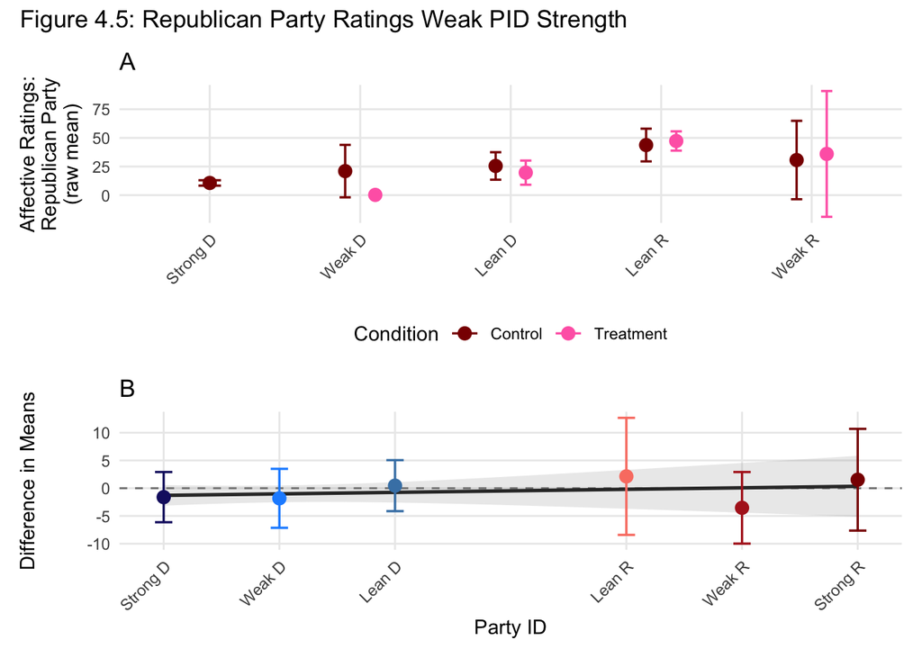

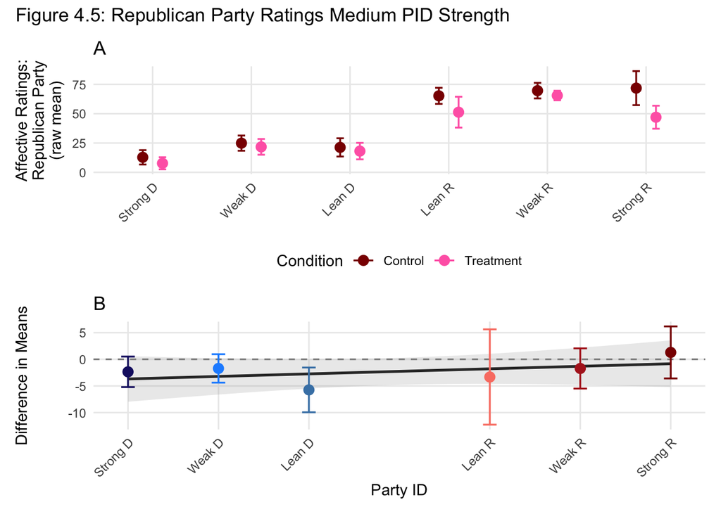

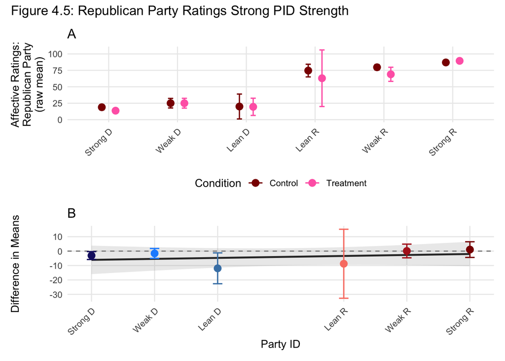

### Hypothesis 6

```r
H6_cov <- lm_robust(ft_dem_post ~ condition_dummy * factor(party_numeric) * PID_bin
                    + condition_dummy * social_closeness
                    + condition_dummy * ft_rep_pre
                    + condition_dummy * ft_dem_pre
                    + ideology_selfreport
                    + maga,
                    data = data_clean, se_type = "HC2")
```

| term | estimate | std.error | statistic | p.value | conf.low | conf.high | df | outcome |
| --- | --- | --- | --- | --- | --- | --- | --- | --- |
| (Intercept) | 1.479 | 1.659 | 0.892 | 0.373 | -1.777 | 4.735 | 747 | ft_dem_post |
| condition_dummy | 3.192 | 3.044 | 1.048 | 0.295 | -2.784 | 9.168 | 747 | ft_dem_post |
| factor(party_numeric)2 | -3.839 | 2.199 | -1.746 | 0.081 | -8.157 | 0.478 | 747 | ft_dem_post |
| factor(party_numeric)3 | 0.843 | 1.540 | 0.548 | 0.584 | -2.180 | 3.866 | 747 | ft_dem_post |
| factor(party_numeric)5 | -0.880 | 1.992 | -0.442 | 0.659 | -4.790 | 3.030 | 747 | ft_dem_post |
| factor(party_numeric)6 | -1.134 | 1.893 | -0.599 | 0.550 | -4.851 | 2.584 | 747 | ft_dem_post |
| factor(party_numeric)7 | -1.432 | 2.360 | -0.607 | 0.544 | -6.066 | 3.201 | 747 | ft_dem_post |
| PID_bin | 0.795 | 0.857 | 0.927 | 0.354 | -0.888 | 2.477 | 747 | ft_dem_post |
| social_closeness | 0.454 | 0.555 | 0.818 | 0.414 | -0.635 | 1.542 | 747 | ft_dem_post |
| ft_rep_pre | 0.012 | 0.016 | 0.774 | 0.439 | -0.019 | 0.043 | 747 | ft_dem_post |
| ft_dem_pre | 0.957 | 0.019 | 49.977 | 0.000 | 0.920 | 0.995 | 747 | ft_dem_post |
| ideology_selfreport | -0.226 | 0.324 | -0.698 | 0.485 | -0.863 | 0.410 | 747 | ft_dem_post |
| maga | -0.018 | 1.072 | -0.017 | 0.986 | -2.123 | 2.087 | 747 | ft_dem_post |
| condition_dummy:factor(party_numeric)2 | 4.748 | 3.708 | 1.280 | 0.201 | -2.532 | 12.029 | 747 | ft_dem_post |
| condition_dummy:factor(party_numeric)3 | -2.409 | 3.108 | -0.775 | 0.439 | -8.511 | 3.693 | 747 | ft_dem_post |
| condition_dummy:factor(party_numeric)5 | 6.483 | 4.623 | 1.402 | 0.161 | -2.592 | 15.559 | 747 | ft_dem_post |
| condition_dummy:factor(party_numeric)6 | -1.327 | 4.389 | -0.302 | 0.762 | -9.944 | 7.290 | 747 | ft_dem_post |
| condition_dummy:factor(party_numeric)7 | 13.409 | 3.417 | 3.924 | 0.000 | 6.700 | 20.118 | 747 | ft_dem_post |
| condition_dummy:PID_bin | 0.822 | 1.685 | 0.488 | 0.626 | -2.486 | 4.129 | 747 | ft_dem_post |
| factor(party_numeric)2:PID_bin | 1.914 | 1.268 | 1.510 | 0.132 | -0.575 | 4.403 | 747 | ft_dem_post |
| factor(party_numeric)3:PID_bin | -2.754 | 2.118 | -1.300 | 0.194 | -6.913 | 1.405 | 747 | ft_dem_post |
| factor(party_numeric)5:PID_bin | -1.905 | 1.178 | -1.618 | 0.106 | -4.217 | 0.406 | 747 | ft_dem_post |
| factor(party_numeric)6:PID_bin | -0.924 | 1.715 | -0.539 | 0.590 | -4.291 | 2.442 | 747 | ft_dem_post |
| factor(party_numeric)7:PID_bin | -0.615 | 1.370 | -0.449 | 0.654 | -3.305 | 2.075 | 747 | ft_dem_post |
| condition_dummy:social_closeness | -0.882 | 0.829 | -1.065 | 0.287 | -2.509 | 0.745 | 747 | ft_dem_post |
| condition_dummy:ft_rep_pre | -0.026 | 0.035 | -0.740 | 0.460 | -0.093 | 0.042 | 747 | ft_dem_post |
| condition_dummy:ft_dem_pre | -0.023 | 0.036 | -0.638 | 0.524 | -0.092 | 0.047 | 747 | ft_dem_post |
| condition_dummy:factor(party_numeric)2:PID_bin | -2.960 | 2.132 | -1.388 | 0.166 | -7.146 | 1.227 | 747 | ft_dem_post |
| condition_dummy:factor(party_numeric)3:PID_bin | 3.636 | 2.763 | 1.316 | 0.189 | -1.788 | 9.059 | 747 | ft_dem_post |
| condition_dummy:factor(party_numeric)5:PID_bin | -3.076 | 3.278 | -0.938 | 0.348 | -9.510 | 3.359 | 747 | ft_dem_post |
| condition_dummy:factor(party_numeric)6:PID_bin | 2.695 | 3.214 | 0.838 | 0.402 | -3.615 | 9.006 | 747 | ft_dem_post |
| condition_dummy:factor(party_numeric)7:PID_bin | -8.109 | 2.984 | -2.718 | 0.007 | -13.967 | -2.251 | 747 | ft_dem_post |

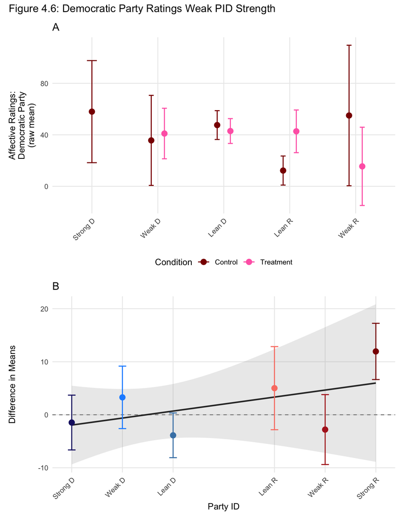

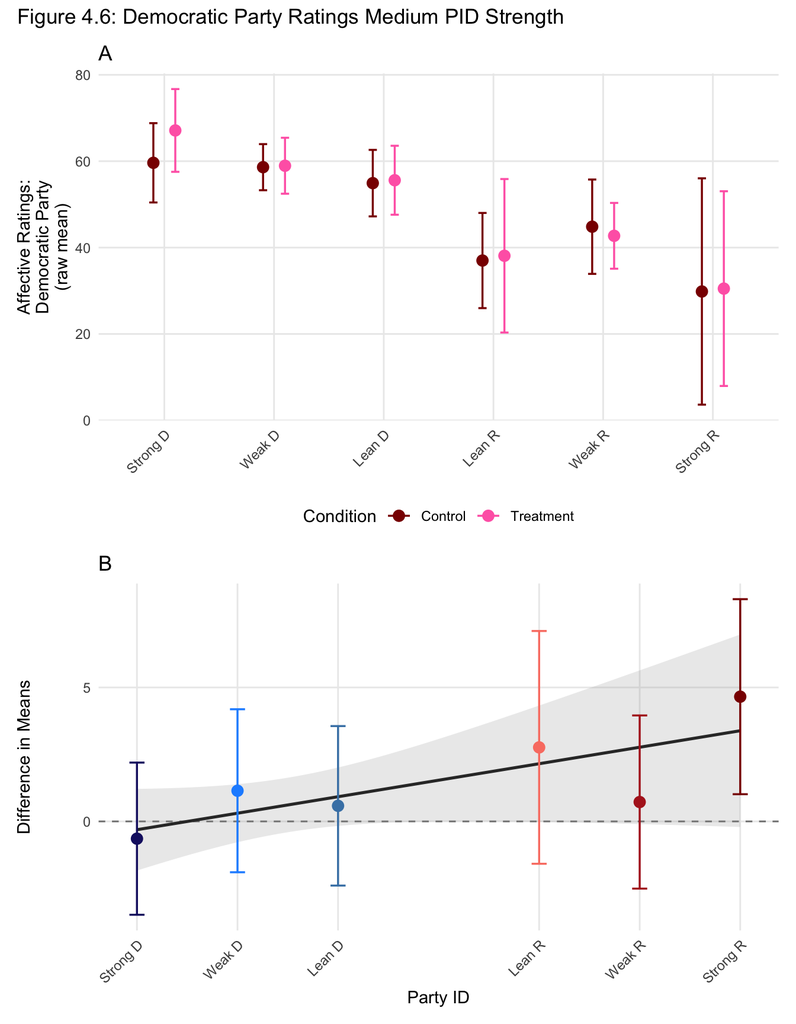

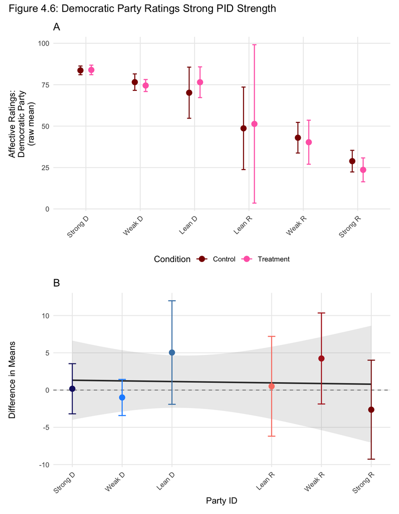

## Scenario-Specific SPV

On the micro level, across each of the six scenarios, I will conduct two Ordinary Least Squares (OLS) linear regression models with heteroskedasticity-robust standard errors, one focused on individual support for political violence and the other on meta-perceptions of Republicans’ support for political violence. For the former, I will create two additional Ordinary Least Squares (OLS) linear regression models with heteroskedasticity-robust standard errors to distinguish between Republicans’ reported SPV and Democrats’ reported SPV within each SPV scenario. Across each of these four models, I plan to regress each of the six scenario-specific measures of SPV separately onto a three-way interaction between condition assignment, the numeric version of the ANES 7-point party identification scale, and the grouped version of partisan self-concept used in Hypotheses 5a through 6c. Additional specified covariates include the interaction between the treatment and social closeness, support for the MAGA movement, and self-reported ideology.

*I deviated from the pre-analysis plan by removing the additional specified covariates from each model, as this simplifies the ability to draw conclusions about the average treatment effect. The only covariates included are PID_dummy, which represents the dichotomous effect of being a Democrat versus a Republican, and PID_bin, the grouped version of partisan self-concept.*

### Scenario: Protesting without a permit

#### Models

```r
# 1.1: form models for:
# A: Individual SPV (Aggregated)
lm_protest_indiv <- lm_robust(SPV_indiv_protest ~ condition_dummy * PID_dummy * PID_bin,
                              data = data_clean, se_type = "HC2")
# B: Meta-Perceptions of Republican SPV
lm_protest_meta_R <- lm_robust(SPV_meta_protest ~ condition_dummy * PID_dummy * PID_bin,
                               data = data_clean, se_type = "HC2")
# C: Individual SPV (Reps only)
lm_R_protest <- lm_robust(spv_Rprotest ~ condition_dummy * PID_bin,
                          data = data_clean, se_type = "HC2")
# D: Individual SPV (Dems only)
lm_D_protest <- lm_robust(spv_Dprotest ~ condition_dummy * PID_bin,
                          data = data_clean, se_type = "HC2")
```

Individual SPV

| term | estimate | std.error | statistic | p.value | conf.low | conf.high | df | outcome |
| --- | --- | --- | --- | --- | --- | --- | --- | --- |
| (Intercept) | 42.795 | 4.136 | 10.346 | 0.000 | 34.675 | 50.915 | 774 | SPV_indiv_protest |
| condition_dummy | 15.132 | 6.411 | 2.360 | 0.019 | 2.547 | 27.718 | 774 | SPV_indiv_protest |
| PID_dummy | -26.558 | 6.080 | -4.368 | 0.000 | -38.492 | -14.623 | 774 | SPV_indiv_protest |
| PID_bin | 4.368 | 2.612 | 1.672 | 0.095 | -0.760 | 9.496 | 774 | SPV_indiv_protest |
| condition_dummy:PID_dummy | 2.301 | 10.215 | 0.225 | 0.822 | -17.752 | 22.355 | 774 | SPV_indiv_protest |
| condition_dummy:PID_bin | -5.930 | 3.960 | -1.498 | 0.135 | -13.704 | 1.843 | 774 | SPV_indiv_protest |
| PID_dummy:PID_bin | 13.091 | 4.024 | 3.253 | 0.001 | 5.191 | 20.990 | 774 | SPV_indiv_protest |
| condition_dummy:PID_dummy:PID_bin | -6.951 | 6.904 | -1.007 | 0.314 | -20.503 | 6.601 | 774 | SPV_indiv_protest |

Meta-Perceptions Republican SPV

| term | estimate | std.error | statistic | p.value | conf.low | conf.high | df | outcome |
| --- | --- | --- | --- | --- | --- | --- | --- | --- |
| (Intercept) | 57.366 | 4.687 | 12.238 | 0.000 | 48.164 | 66.567 | 777 | SPV_meta_protest |
| condition_dummy | 10.715 | 6.962 | 1.539 | 0.124 | -2.952 | 24.381 | 777 | SPV_meta_protest |
| PID_dummy | -9.016 | 6.890 | -1.309 | 0.191 | -22.542 | 4.510 | 777 | SPV_meta_protest |
| PID_bin | -0.929 | 2.888 | -0.322 | 0.748 | -6.599 | 4.741 | 777 | SPV_meta_protest |
| condition_dummy:PID_dummy | 8.520 | 9.999 | 0.852 | 0.394 | -11.108 | 28.148 | 777 | SPV_meta_protest |
| condition_dummy:PID_bin | -2.945 | 4.218 | -0.698 | 0.485 | -11.225 | 5.335 | 777 | SPV_meta_protest |
| PID_dummy:PID_bin | 6.206 | 4.309 | 1.440 | 0.150 | -2.253 | 14.665 | 777 | SPV_meta_protest |
| condition_dummy:PID_dummy:PID_bin | -10.385 | 6.528 | -1.591 | 0.112 | -23.200 | 2.430 | 777 | SPV_meta_protest |

Individual SPV (Republicans Only)

| term | estimate | std.error | statistic | p.value | conf.low | conf.high | df | outcome |
| --- | --- | --- | --- | --- | --- | --- | --- | --- |
| (Intercept) | 16.237 | 4.455 | 3.644 | 0.000 | 7.463 | 25.012 | 253 | spv_Rprotest |
| condition_dummy | 17.434 | 7.953 | 2.192 | 0.029 | 1.772 | 33.096 | 253 | spv_Rprotest |
| PID_bin | 17.458 | 3.061 | 5.703 | 0.000 | 11.430 | 23.487 | 253 | spv_Rprotest |
| condition_dummy:PID_bin | -12.881 | 5.655 | -2.278 | 0.024 | -24.018 | -1.745 | 253 | spv_Rprotest |

Individual SPV (Democrats Only)

| term | estimate | std.error | statistic | p.value | conf.low | conf.high | df | outcome |
| --- | --- | --- | --- | --- | --- | --- | --- | --- |
| (Intercept) | 42.795 | 4.136 | 10.346 | 0.000 | 34.669 | 50.921 | 521 | spv_Dprotest |
| condition_dummy | 15.132 | 6.411 | 2.360 | 0.019 | 2.537 | 27.728 | 521 | spv_Dprotest |
| PID_bin | 4.368 | 2.612 | 1.672 | 0.095 | -0.764 | 9.500 | 521 | spv_Dprotest |
| condition_dummy:PID_bin | -5.930 | 3.960 | -1.498 | 0.135 | -13.710 | 1.849 | 521 | spv_Dprotest |

#### Party ID (Dummy)

```r
# form emmeans and contrast matrices for Individual SPV (Aggregated)
emm_protest_indiv <- emmeans(lm_protest_indiv, ~ condition_dummy * PID_dummy,
                             vcov. = vcov(lm_protest_indiv))
emm_protest_indiv_df <- as.data.frame(confint(emm_protest_indiv)) %>%
  mutate(
    condition_dummy = factor(condition_dummy, levels = c(0, 1),
                             labels = c("Control", "Treatment")),
    PID_dummy = factor(PID_dummy, levels = c(0, 1),
                       labels = c("Democrat", "Republican")),
    group = interaction(condition_dummy, PID_dummy))
contr_protest_indiv <- contrast(emm_protest_indiv,
                                method = list(
                                  "Control D vs. Control R"     = c(-1,  0,  1,  0),
                                  "Control D vs. Treatment D"   = c(-1,  1,  0,  0),
                                  "Control R vs. Treatment R"   = c( 0,  0, -1,  1),
                                  "Treatment D vs. Treatment R" = c( 0, -1,  0,  1)))
contr_protest_indiv_df <- as.data.frame(confint(contr_protest_indiv))
contr_table_protest_indiv <- summary(contr_protest_indiv) |>
  as.data.frame() |>
  dplyr::select(contrast, estimate, SE, df, t.ratio, p.value)
```

| contrast | estimate | SE | df | t.ratio | p.value |
| --- | --- | --- | --- | --- | --- |
| Control D vs. Control R | -6.830133 | 2.951703 | 774 | -2.3139637 | 0.0209308 |
| Control D vs. Treatment D | 6.195672 | 2.550776 | 774 | 2.4289363 | 0.0153699 |
| Control R vs. Treatment R | -1.978148 | 3.827324 | 774 | -0.5168488 | 0.6054093 |
| Treatment D vs. Treatment R | -15.003953 | 3.527367 | 774 | -4.2535843 | 0.0000236 |

```r
# form emmeans and contrast matrices for Meta-Perceptions of Republican SPV
emm_protest_meta_R <- emmeans(lm_protest_meta_R, ~ condition_dummy * PID_dummy,
                              vcov. = vcov(lm_protest_meta_R))
emm_protest_meta_R_df <- as.data.frame(confint(emm_protest_meta_R)) %>%
  mutate(
    condition_dummy = factor(condition_dummy, levels = c(0, 1),
                             labels = c("Control", "Treatment")),
    PID_dummy = factor(PID_dummy, levels = c(0, 1),
                       labels = c("Democrat", "Republican")),
    group = interaction(condition_dummy, PID_dummy))
contr_protest_meta_R <- contrast(emm_protest_meta_R,
                                 method = list(
                                   "Control D vs. Control R"     = c(-1,  0,  1,  0),
                                   "Control D vs. Treatment D"   = c(-1,  1,  0,  0),
                                   "Control R vs. Treatment R"   = c( 0,  0, -1,  1),
                                   "Treatment D vs. Treatment R" = c( 0, -1,  0,  1)))
contr_protest_meta_R_df <- as.data.frame(confint(contr_protest_meta_R))
contr_table_protest_meta_R <- summary(contr_protest_meta_R) |>
  as.data.frame() |>
  dplyr::select(contrast, estimate, SE, df, t.ratio, p.value)
```

| contrast | estimate | SE | df | t.ratio | p.value |
| --- | --- | --- | --- | --- | --- |
| Control D vs. Control R | 0.3363275 | 2.859830 | 777 | 0.1176040 | 0.9064118 |
| Control D vs. Treatment D | 6.2770729 | 2.672940 | 777 | 2.3483778 | 0.0191051 |
| Control R vs. Treatment R | -0.8533573 | 3.460719 | 777 | -0.2465838 | 0.8052955 |
| Treatment D vs. Treatment R | -6.7941027 | 3.307953 | 777 | -2.0538690 | 0.0403225 |

#### Party ID (7-pt)

```r
# form emmeans and contrast matrices for Individual SPV (Aggregated)
protest_indiv_partyaffil <- lm_robust(SPV_indiv_protest ~ condition_dummy * party_numeric, data = data_clean, se_type = "HC2")
emm_protest_indiv_partyaffil<- emmeans(protest_indiv_partyaffil, ~ condition_dummy * party_numeric,
                                       at = list(party_numeric = c(1, 2, 3, 5, 6, 7)),
                                       vcov. = vcov(protest_indiv_partyaffil))
contr_protest_indiv_partyaffil<- contrast(emm_protest_indiv_partyaffil,
                                          method = list("Treatment - Control" = c(-1, 1)),
                                          by = "party_numeric")
contr_protest_indiv_partyaffil_df <- confint(contr_protest_indiv_partyaffil) |>
  as.data.frame() |>
  mutate(
    party_label = factor(party_numeric, levels = c(1, 2, 3, 5, 6, 7),
                         labels = c("Strong D","Weak D","Lean D","Lean R","Weak R","Strong R")),
    model = "Individual Ratings")
```

| contrast | party_numeric | estimate | SE | df | lower.CL | upper.CL | party_label | model |
| --- | --- | --- | --- | --- | --- | --- | --- | --- |
| Treatment - Control | 1 | 7.0566203 | 2.959668 | 782 | 1.2467864 | 12.866454 | Strong D | Individual Ratings |
| Treatment - Control | 2 | 5.4523769 | 2.371865 | 782 | 0.7964009 | 10.108353 | Weak D | Individual Ratings |
| Treatment - Control | 3 | 3.8481336 | 2.128025 | 782 | -0.3291845 | 8.025452 | Lean D | Individual Ratings |
| Treatment - Control | 5 | 0.6396468 | 2.905838 | 782 | -5.0645201 | 6.343814 | Lean R | Individual Ratings |
| Treatment - Control | 6 | -0.9645965 | 3.668318 | 782 | -8.1655119 | 6.236319 | Weak R | Individual Ratings |
| Treatment - Control | 7 | -2.5688399 | 4.528338 | 782 | -11.4579778 | 6.320298 | Strong R | Individual Ratings |

```r
# form emmeans and contrast matrices for Meta-Perceptions of Republican SPV
protest_meta_R_partyaffil <- lm_robust(SPV_meta_protest ~ condition_dummy * party_numeric, data = data_clean, se_type = "HC2")
emm_protest_meta_R_partyaffil<- emmeans(protest_meta_R_partyaffil, ~ condition_dummy * party_numeric,
                                        at = list(party_numeric = c(1, 2, 3, 5, 6, 7)),
                                        vcov. = vcov(protest_meta_R_partyaffil))
contr_protest_meta_R_partyaffil<- contrast(emm_protest_meta_R_partyaffil,
                                           method = list("Treatment - Control" = c(-1, 1)),
                                           by = "party_numeric")
contr_protest_meta_R_partyaffil_df <- confint(contr_protest_meta_R_partyaffil) |>
  as.data.frame() |>
  mutate(
    party_label = factor(party_numeric, levels = c(1, 2, 3, 5, 6, 7),
                         labels = c("Strong D","Weak D","Lean D","Lean R","Weak R","Strong R")),
    model = "Meta-Perceptions of Republicans' Ratings")
```

| contrast | party_numeric | estimate | SE | df | lower.CL | upper.CL | party_label | model |
| --- | --- | --- | --- | --- | --- | --- | --- | --- |
| Treatment - Control | 1 | 6.0762027 | 3.053646 | 785 | 0.0819242 | 12.070481 | Strong D | Meta-Perceptions of Republicans’ Ratings |
| Treatment - Control | 2 | 5.1819775 | 2.460482 | 785 | 0.3520735 | 10.011881 | Weak D | Meta-Perceptions of Republicans’ Ratings |
| Treatment - Control | 3 | 4.2877522 | 2.125921 | 785 | 0.1145901 | 8.460914 | Lean D | Meta-Perceptions of Republicans’ Ratings |
| Treatment - Control | 5 | 2.4993018 | 2.580640 | 785 | -2.5664697 | 7.565073 | Lean R | Meta-Perceptions of Republicans’ Ratings |
| Treatment - Control | 6 | 1.6050766 | 3.214701 | 785 | -4.7053504 | 7.915503 | Weak R | Meta-Perceptions of Republicans’ Ratings |
| Treatment - Control | 7 | 0.7108514 | 3.968028 | 785 | -7.0783494 | 8.500052 | Strong R | Meta-Perceptions of Republicans’ Ratings |

#### Party ID (7-pt) + Partisan Self-Concept

```r
lm_protest_indiv_R_7 <- lm_robust(SPV_indiv_protest ~ condition_dummy * party_numeric * PID_bin,
                                  data = data_clean, se_type = "HC2")
emm_protest_indiv_R_7<- emmeans(lm_protest_indiv_R_7, ~ condition_dummy | party_numeric,
                                at = list(party_numeric = c(1, 2, 3, 5, 6, 7)),
                                vcov. = vcov(lm_protest_indiv_R_7))
contr_protest_indiv_R_7<- contrast(emm_protest_indiv_R_7,
                                   method = list("Treatment - Control" = c(-1, 1)),
                                   by = "party_numeric")
contr_protest_indiv_R_7_df <- as.data.frame(confint(contr_protest_indiv_R_7))
contr_table_protest_indiv_R_7_df <- summary(contr_protest_indiv_R_7) |>
  as.data.frame() |>
  dplyr::select(contrast, party_numeric, estimate, SE, df, t.ratio, p.value) |>
  mutate(party_label = factor(party_numeric, levels = c(1, 2, 3, 5, 6, 7),
                              labels = c("Strong D","Weak D","Lean D","Lean R","Weak R","Strong R")))
```

| contrast | party_numeric | estimate | SE | df | t.ratio | p.value | party_label |
| --- | --- | --- | --- | --- | --- | --- | --- |
| Treatment - Control | 1 | 6.9789524 | 3.059601 | 774 | 2.2810007 | 0.0228193 | Strong D |
| Treatment - Control | 2 | 5.4979017 | 2.452873 | 774 | 2.2414131 | 0.0252820 | Weak D |
| Treatment - Control | 3 | 4.0168511 | 2.163984 | 774 | 1.8562300 | 0.0638006 | Lean D |
| Treatment - Control | 5 | 1.0547498 | 2.836854 | 774 | 0.3718027 | 0.7101415 | Lean R |
| Treatment - Control | 6 | -0.4263008 | 3.570212 | 774 | -0.1194049 | 0.9049856 | Weak R |
| Treatment - Control | 7 | -1.9073515 | 4.410884 | 774 | -0.4324193 | 0.6655571 | Strong R |

```r
lm_protest_meta_R_7 <- lm_robust(SPV_meta_protest ~ condition_dummy * party_numeric * PID_bin,
                                 data = data_clean, se_type = "HC2")
emm_protest_meta_R_7<- emmeans(lm_protest_meta_R_7, ~ condition_dummy | party_numeric,
                               at = list(party_numeric = c(1, 2, 3, 5, 6, 7)),
                               vcov. = vcov(lm_protest_meta_R_7))
contr_protest_meta_R_7<- contrast(emm_protest_meta_R_7,
                                  method = list("Treatment - Control" = c(-1, 1)),
                                  by = "party_numeric")
contr_protest_meta_R_7_df <- as.data.frame(confint(contr_protest_meta_R_7))
contr_table_protest_meta_R_7_df <- summary(contr_protest_meta_R_7) |>
  as.data.frame() |>
  dplyr::select(contrast, party_numeric, estimate, SE, df, t.ratio, p.value) |>
  mutate(party_label = factor(party_numeric, levels = c(1, 2, 3, 5, 6, 7),
                              labels = c("Strong D","Weak D","Lean D","Lean R","Weak R","Strong R")))
```

| contrast | party_numeric | estimate | SE | df | t.ratio | p.value | party_label |
| --- | --- | --- | --- | --- | --- | --- | --- |
| Treatment - Control | 1 | 4.970842 | 3.261950 | 777 | 1.5238864 | 0.1279440 | Strong D |
| Treatment - Control | 2 | 4.407223 | 2.605459 | 777 | 1.6915342 | 0.0911358 | Weak D |
| Treatment - Control | 3 | 3.843604 | 2.199456 | 777 | 1.7475253 | 0.0809413 | Lean D |
| Treatment - Control | 5 | 2.716367 | 2.576675 | 777 | 1.0542141 | 0.2921126 | Lean R |
| Treatment - Control | 6 | 2.152748 | 3.223618 | 777 | 0.6678049 | 0.5044564 | Weak R |
| Treatment - Control | 7 | 1.589129 | 4.005654 | 777 | 0.3967215 | 0.6916818 | Strong R |

#### Factor models for panel plots

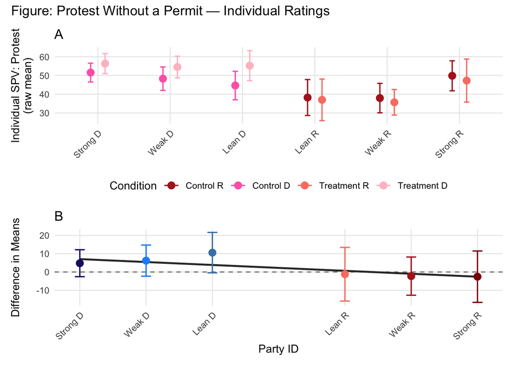

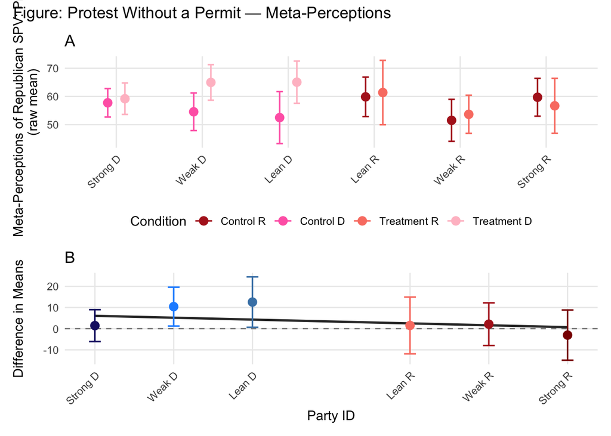

```r
protest_indiv_factor <- lm_robust(SPV_indiv_protest ~ condition_dummy * factor(party_numeric),
                                  data = data_clean, se_type = "HC2")
emm_protest_indiv_factor <- emmeans(protest_indiv_factor, ~ condition_dummy | party_numeric,
                                    vcov. = vcov(protest_indiv_factor))
contr_protest_indiv_factor_df <- confint(contrast(emm_protest_indiv_factor,
                                                  method = list("Treatment - Control" = c(-1, 1)),
                                                  by = "party_numeric")) |>
  as.data.frame() |>
  mutate(party_numeric = as.numeric(as.character(party_numeric)))

protest_meta_R_factor <- lm_robust(SPV_meta_protest ~ condition_dummy * factor(party_numeric),
                                   data = data_clean, se_type = "HC2")
emm_protest_meta_R_factor <- emmeans(protest_meta_R_factor, ~ condition_dummy | party_numeric,
                                     vcov. = vcov(protest_meta_R_factor))
contr_protest_meta_R_factor_df <- confint(contrast(emm_protest_meta_R_factor,
                                                   method = list("Treatment - Control" = c(-1, 1)),
                                                   by = "party_numeric")) |>
  as.data.frame() |>
  mutate(party_numeric = as.numeric(as.character(party_numeric)))

p_protest_indiv <- make_SPV_panels(
  "SPV_indiv_protest",
  contr_protest_indiv_partyaffil_df,
  contr_protest_indiv_factor_df,
  "Individual SPV: Protest\n(raw mean)",
  "Figure: Protest Without a Permit — Individual Ratings",
  color_A = c("Control R" = "firebrick", "Treatment R" = "salmon",
              "Control D" = "hotpink",   "Treatment D" = "pink"))

p_protest_meta_R <- make_SPV_panels(
  "SPV_meta_protest",
  contr_protest_meta_R_partyaffil_df,
  contr_protest_meta_R_factor_df,
  "Meta-Perceptions of Republican SPV: Protest\n(raw mean)",
  "Figure: Protest Without a Permit — Meta-Perceptions",
  color_A = c("Control R" = "firebrick", "Treatment R" = "salmon",
              "Control D" = "hotpink",   "Treatment D" = "pink"))
```

### Scenario: Vandalizing opposing party’s signs

#### Models

```r
# 1.1: form models for:
# A: Individual SPV (Aggregated)
lm_vandalize_indiv <- lm_robust(SPV_indiv_vandalize ~ condition_dummy * PID_dummy * PID_bin,
                              data = data_clean, se_type = "HC2")
# B: Meta-Perceptions of Republican SPV
lm_vandalize_meta_R <- lm_robust(SPV_meta_vandalize ~ condition_dummy * PID_dummy * PID_bin,
                               data = data_clean, se_type = "HC2")
# C: Individual SPV (Reps only)
lm_R_vandalize <- lm_robust(spv_Rvandalize ~ condition_dummy * PID_bin,
                          data = data_clean, se_type = "HC2")
# D: Individual SPV (Dems only)
lm_D_vandalize <- lm_robust(spv_Dvandalize ~ condition_dummy * PID_bin,
                          data = data_clean, se_type = "HC2")
```

Individual SPV

| term | estimate | std.error | statistic | p.value | conf.low | conf.high | df | outcome |
| --- | --- | --- | --- | --- | --- | --- | --- | --- |
| (Intercept) | 32.932 | 4.171 | 7.895 | 0.000 | 24.744 | 41.121 | 772 | SPV_indiv_vandalize |
| condition_dummy | 7.143 | 7.003 | 1.020 | 0.308 | -6.605 | 20.891 | 772 | SPV_indiv_vandalize |
| PID_dummy | -28.169 | 6.052 | -4.655 | 0.000 | -40.049 | -16.289 | 772 | SPV_indiv_vandalize |
| PID_bin | -2.083 | 2.547 | -0.818 | 0.414 | -7.083 | 2.917 | 772 | SPV_indiv_vandalize |
| condition_dummy:PID_dummy | 2.273 | 9.608 | 0.237 | 0.813 | -16.587 | 21.133 | 772 | SPV_indiv_vandalize |
| condition_dummy:PID_bin | -0.132 | 4.183 | -0.032 | 0.975 | -8.345 | 8.080 | 772 | SPV_indiv_vandalize |
| PID_dummy:PID_bin | 15.264 | 3.983 | 3.832 | 0.000 | 7.445 | 23.082 | 772 | SPV_indiv_vandalize |
| condition_dummy:PID_dummy:PID_bin | -6.212 | 6.333 | -0.981 | 0.327 | -18.644 | 6.220 | 772 | SPV_indiv_vandalize |

Meta-Perceptions Republican SPV

| term | estimate | std.error | statistic | p.value | conf.low | conf.high | df | outcome |
| --- | --- | --- | --- | --- | --- | --- | --- | --- |
| (Intercept) | 47.768 | 4.808 | 9.934 | 0.000 | 38.329 | 57.207 | 773 | SPV_meta_vandalize |
| condition_dummy | 13.445 | 7.576 | 1.775 | 0.076 | -1.427 | 28.317 | 773 | SPV_meta_vandalize |
| PID_dummy | -22.082 | 6.643 | -3.324 | 0.001 | -35.122 | -9.042 | 773 | SPV_meta_vandalize |
| PID_bin | -0.377 | 2.990 | -0.126 | 0.900 | -6.247 | 5.492 | 773 | SPV_meta_vandalize |
| condition_dummy:PID_dummy | 11.520 | 11.305 | 1.019 | 0.308 | -10.671 | 33.712 | 773 | SPV_meta_vandalize |
| condition_dummy:PID_bin | -4.542 | 4.563 | -0.995 | 0.320 | -13.500 | 4.415 | 773 | SPV_meta_vandalize |
| PID_dummy:PID_bin | 8.770 | 4.349 | 2.017 | 0.044 | 0.233 | 17.307 | 773 | SPV_meta_vandalize |
| condition_dummy:PID_dummy:PID_bin | -10.516 | 7.301 | -1.440 | 0.150 | -24.847 | 3.815 | 773 | SPV_meta_vandalize |

Individual SPV (Republicans Only)

| term | estimate | std.error | statistic | p.value | conf.low | conf.high | df | outcome |
| --- | --- | --- | --- | --- | --- | --- | --- | --- |
| (Intercept) | 4.763 | 4.385 | 1.086 | 0.278 | -3.872 | 13.398 | 254 | spv_Rvandalize |
| condition_dummy | 9.416 | 6.577 | 1.432 | 0.153 | -3.537 | 22.369 | 254 | spv_Rvandalize |
| PID_bin | 13.181 | 3.062 | 4.305 | 0.000 | 7.151 | 19.211 | 254 | spv_Rvandalize |
| condition_dummy:PID_bin | -6.344 | 4.754 | -1.334 | 0.183 | -15.707 | 3.019 | 254 | spv_Rvandalize |

Individual SPV (Democrats Only)

| term | estimate | std.error | statistic | p.value | conf.low | conf.high | df | outcome |
| --- | --- | --- | --- | --- | --- | --- | --- | --- |
| (Intercept) | 32.932 | 4.171 | 7.895 | 0.000 | 24.738 | 41.127 | 518 | spv_Dvandalize |
| condition_dummy | 7.143 | 7.003 | 1.020 | 0.308 | -6.616 | 20.902 | 518 | spv_Dvandalize |
| PID_bin | -2.083 | 2.547 | -0.818 | 0.414 | -7.087 | 2.921 | 518 | spv_Dvandalize |
| condition_dummy:PID_bin | -0.132 | 4.183 | -0.032 | 0.975 | -8.351 | 8.086 | 518 | spv_Dvandalize |

#### Party ID (Dummy)

```r
# form emmeans and contrast matrices for Individual SPV (Aggregated)
emm_vandalize_indiv <- emmeans(lm_vandalize_indiv, ~ condition_dummy * PID_dummy,
                             vcov. = vcov(lm_vandalize_indiv))
emm_vandalize_indiv_df <- as.data.frame(confint(emm_vandalize_indiv)) %>%
  mutate(
    condition_dummy = factor(condition_dummy, levels = c(0, 1),
                             labels = c("Control", "Treatment")),
    PID_dummy = factor(PID_dummy, levels = c(0, 1),
                       labels = c("Democrat", "Republican")),
    group = interaction(condition_dummy, PID_dummy))
contr_vandalize_indiv <- contrast(emm_vandalize_indiv,
                                method = list(
                                  "Control D vs. Control R"     = c(-1,  0,  1,  0),
                                  "Control D vs. Treatment D"   = c(-1,  1,  0,  0),
                                  "Control R vs. Treatment R"   = c( 0,  0, -1,  1),
                                  "Treatment D vs. Treatment R" = c( 0, -1,  0,  1)))
contr_vandalize_indiv_df <- as.data.frame(confint(contr_vandalize_indiv))
contr_table_vandalize_indiv <- summary(contr_vandalize_indiv) |>
  as.data.frame() |>
  dplyr::select(contrast, estimate, SE, df, t.ratio, p.value)
```

| contrast | estimate | SE | df | t.ratio | p.value |
| --- | --- | --- | --- | --- | --- |
| Control D vs. Control R | -5.1666652 | 2.753057 | 772 | -1.8767011 | 0.0609360 |
| Control D vs. Treatment D | 6.9436643 | 2.563970 | 772 | 2.7081689 | 0.0069153 |
| Control R vs. Treatment R | -0.1446896 | 3.389855 | 772 | -0.0426831 | 0.9659652 |
| Treatment D vs. Treatment R | -12.2550191 | 3.238169 | 772 | -3.7845525 | 0.0001659 |

```r
# form emmeans and contrast matrices for Meta-Perceptions of Republican SPV
emm_vandalize_meta_R <- emmeans(lm_vandalize_meta_R, ~ condition_dummy * PID_dummy,
                              vcov. = vcov(lm_vandalize_meta_R))
emm_vandalize_meta_R_df <- as.data.frame(confint(emm_vandalize_meta_R)) %>%
  mutate(
    condition_dummy = factor(condition_dummy, levels = c(0, 1),
                             labels = c("Control", "Treatment")),
    PID_dummy = factor(PID_dummy, levels = c(0, 1),
                       labels = c("Democrat", "Republican")),
    group = interaction(condition_dummy, PID_dummy))
contr_vandalize_meta_R <- contrast(emm_vandalize_meta_R,
                                 method = list(
                                   "Control D vs. Control R"     = c(-1,  0,  1,  0),
                                   "Control D vs. Treatment D"   = c(-1,  1,  0,  0),
                                   "Control R vs. Treatment R"   = c( 0,  0, -1,  1),
                                   "Treatment D vs. Treatment R" = c( 0, -1,  0,  1)))
contr_vandalize_meta_R_df <- as.data.frame(confint(contr_vandalize_meta_R))
contr_table_vandalize_meta_R <- summary(contr_vandalize_meta_R) |>
  as.data.frame() |>
  dplyr::select(contrast, estimate, SE, df, t.ratio, p.value)
```

| contrast | estimate | SE | df | t.ratio | p.value |
| --- | --- | --- | --- | --- | --- |
| Control D vs. Control R | -8.865556 | 2.946239 | 773 | -3.0091100 | 0.0027053 |
| Control D vs. Treatment D | 6.599702 | 2.892820 | 773 | 2.2814076 | 0.0227955 |
| Control R vs. Treatment R | 2.271952 | 3.516133 | 773 | 0.6461508 | 0.5183735 |
| Treatment D vs. Treatment R | -13.193306 | 3.471495 | 773 | -3.8004682 | 0.0001558 |

#### Party ID (7-pt)

```r
# form emmeans and contrast matrices for Individual SPV (Aggregated)
vandalize_indiv_partyaffil <- lm_robust(SPV_indiv_vandalize ~ condition_dummy * party_numeric, data = data_clean, se_type = "HC2")
emm_vandalize_indiv_partyaffil<- emmeans(vandalize_indiv_partyaffil, ~ condition_dummy * party_numeric,
                                       at = list(party_numeric = c(1, 2, 3, 5, 6, 7)),
                                       vcov. = vcov(vandalize_indiv_partyaffil))
contr_vandalize_indiv_partyaffil<- contrast(emm_vandalize_indiv_partyaffil,
                                          method = list("Treatment - Control" = c(-1, 1)),
                                          by = "party_numeric")
contr_vandalize_indiv_partyaffil_df <- confint(contr_vandalize_indiv_partyaffil) |>
  as.data.frame() |>
  mutate(
    party_label = factor(party_numeric, levels = c(1, 2, 3, 5, 6, 7),
                         labels = c("Strong D","Weak D","Lean D","Lean R","Weak R","Strong R")),
    model = "Individual Ratings")
```

| contrast | party_numeric | estimate | SE | df | lower.CL | upper.CL | party_label | model |
| --- | --- | --- | --- | --- | --- | --- | --- | --- |
| Treatment - Control | 1 | 8.0913299 | 2.930071 | 780 | 2.3395716 | 13.843088 | Strong D | Individual Ratings |
| Treatment - Control | 2 | 6.4550897 | 2.355784 | 780 | 1.8306622 | 11.079517 | Weak D | Individual Ratings |
| Treatment - Control | 3 | 4.8188496 | 2.052619 | 780 | 0.7895374 | 8.848162 | Lean D | Individual Ratings |
| Treatment - Control | 5 | 1.5463693 | 2.576369 | 780 | -3.5110681 | 6.603807 | Lean R | Individual Ratings |
| Treatment - Control | 6 | -0.0898709 | 3.224682 | 780 | -6.4199547 | 6.240213 | Weak R | Individual Ratings |
| Treatment - Control | 7 | -1.7261110 | 3.982286 | 780 | -9.5433785 | 6.091156 | Strong R | Individual Ratings |

```r
# form emmeans and contrast matrices for Meta-Perceptions of Republican SPV
vandalize_meta_R_partyaffil <- lm_robust(SPV_meta_vandalize ~ condition_dummy * party_numeric, data = data_clean, se_type = "HC2")
emm_vandalize_meta_R_partyaffil<- emmeans(vandalize_meta_R_partyaffil, ~ condition_dummy * party_numeric,
                                        at = list(party_numeric = c(1, 2, 3, 5, 6, 7)),
                                        vcov. = vcov(vandalize_meta_R_partyaffil))
contr_vandalize_meta_R_partyaffil<- contrast(emm_vandalize_meta_R_partyaffil,
                                           method = list("Treatment - Control" = c(-1, 1)),
                                           by = "party_numeric")
contr_vandalize_meta_R_partyaffil_df <- confint(contr_vandalize_meta_R_partyaffil) |>
  as.data.frame() |>
  mutate(
    party_label = factor(party_numeric, levels = c(1, 2, 3, 5, 6, 7),
                         labels = c("Strong D","Weak D","Lean D","Lean R","Weak R","Strong R")),
    model = "Meta-Perceptions of Republicans' Ratings")
```

| contrast | party_numeric | estimate | SE | df | lower.CL | upper.CL | party_label | model |
| --- | --- | --- | --- | --- | --- | --- | --- | --- |
| Treatment - Control | 1 | 6.532577 | 3.269176 | 781 | 0.1151645 | 12.949988 | Strong D | Meta-Perceptions of Republicans’ Ratings |
| Treatment - Control | 2 | 6.034259 | 2.641108 | 781 | 0.8497477 | 11.218770 | Weak D | Meta-Perceptions of Republicans’ Ratings |
| Treatment - Control | 3 | 5.535941 | 2.270913 | 781 | 1.0781248 | 9.993758 | Lean D | Meta-Perceptions of Republicans’ Ratings |
| Treatment - Control | 5 | 4.539306 | 2.683505 | 781 | -0.7284307 | 9.807042 | Lean R | Meta-Perceptions of Republicans’ Ratings |
| Treatment - Control | 6 | 4.040988 | 3.326223 | 781 | -2.4884067 | 10.570383 | Weak R | Meta-Perceptions of Republicans’ Ratings |
| Treatment - Control | 7 | 3.542671 | 4.101215 | 781 | -4.5080400 | 11.593381 | Strong R | Meta-Perceptions of Republicans’ Ratings |

#### Party ID (7-pt) + Partisan Self-Concept

```r
lm_vandalize_indiv_R_7 <- lm_robust(SPV_indiv_vandalize ~ condition_dummy * party_numeric * PID_bin,
                                  data = data_clean, se_type = "HC2")
emm_vandalize_indiv_R_7<- emmeans(lm_vandalize_indiv_R_7, ~ condition_dummy | party_numeric,
                                at = list(party_numeric = c(1, 2, 3, 5, 6, 7)),
                                vcov. = vcov(lm_vandalize_indiv_R_7))
contr_vandalize_indiv_R_7<- contrast(emm_vandalize_indiv_R_7,
                                   method = list("Treatment - Control" = c(-1, 1)),
                                   by = "party_numeric")
contr_vandalize_indiv_R_7_df <- as.data.frame(confint(contr_vandalize_indiv_R_7))
contr_table_vandalize_indiv_R_7_df <- summary(contr_vandalize_indiv_R_7) |>
  as.data.frame() |>
  dplyr::select(contrast, party_numeric, estimate, SE, df, t.ratio, p.value) |>
  mutate(party_label = factor(party_numeric, levels = c(1, 2, 3, 5, 6, 7),
                              labels = c("Strong D","Weak D","Lean D","Lean R","Weak R","Strong R")))
```

| contrast | party_numeric | estimate | SE | df | t.ratio | p.value | party_label |
| --- | --- | --- | --- | --- | --- | --- | --- |
| Treatment - Control | 1 | 7.5900529 | 3.192076 | 772 | 2.3777796 | 0.0176598 | Strong D |
| Treatment - Control | 2 | 6.2708727 | 2.539107 | 772 | 2.4697156 | 0.0137373 | Weak D |
| Treatment - Control | 3 | 4.9516925 | 2.132891 | 772 | 2.3215870 | 0.0205146 | Lean D |
| Treatment - Control | 5 | 2.3133321 | 2.507363 | 772 | 0.9226156 | 0.3564958 | Lean R |
| Treatment - Control | 6 | 0.9941519 | 3.149977 | 772 | 0.3156061 | 0.7523868 | Weak R |
| Treatment - Control | 7 | -0.3250284 | 3.924574 | 772 | -0.0828188 | 0.9340171 | Strong R |

```r
lm_vandalize_meta_R_7 <- lm_robust(SPV_meta_vandalize ~ condition_dummy * party_numeric * PID_bin,
                                 data = data_clean, se_type = "HC2")
emm_vandalize_meta_R_7<- emmeans(lm_vandalize_meta_R_7, ~ condition_dummy | party_numeric,
                               at = list(party_numeric = c(1, 2, 3, 5, 6, 7)),
                               vcov. = vcov(lm_vandalize_meta_R_7))
contr_vandalize_meta_R_7<- contrast(emm_vandalize_meta_R_7,
                                  method = list("Treatment - Control" = c(-1, 1)),
                                  by = "party_numeric")
contr_vandalize_meta_R_7_df <- as.data.frame(confint(contr_vandalize_meta_R_7))
contr_table_vandalize_meta_R_7_df <- summary(contr_vandalize_meta_R_7) |>
  as.data.frame() |>
  dplyr::select(contrast, party_numeric, estimate, SE, df, t.ratio, p.value) |>
  mutate(party_label = factor(party_numeric, levels = c(1, 2, 3, 5, 6, 7),
                              labels = c("Strong D","Weak D","Lean D","Lean R","Weak R","Strong R")))
```

| contrast | party_numeric | estimate | SE | df | t.ratio | p.value | party_label |
| --- | --- | --- | --- | --- | --- | --- | --- |
| Treatment - Control | 1 | 5.531969 | 3.531539 | 773 | 1.566447 | 0.1176532 | Strong D |
| Treatment - Control | 2 | 5.320441 | 2.817176 | 773 | 1.888572 | 0.0593233 | Weak D |
| Treatment - Control | 3 | 5.108912 | 2.349322 | 773 | 2.174632 | 0.0299602 | Lean D |
| Treatment - Control | 5 | 4.685854 | 2.653172 | 773 | 1.766133 | 0.0777683 | Lean R |
| Treatment - Control | 6 | 4.474325 | 3.313080 | 773 | 1.350503 | 0.1772499 | Weak R |
| Treatment - Control | 7 | 4.262796 | 4.126959 | 773 | 1.032914 | 0.3019669 | Strong R |

#### Factor models for panel plots

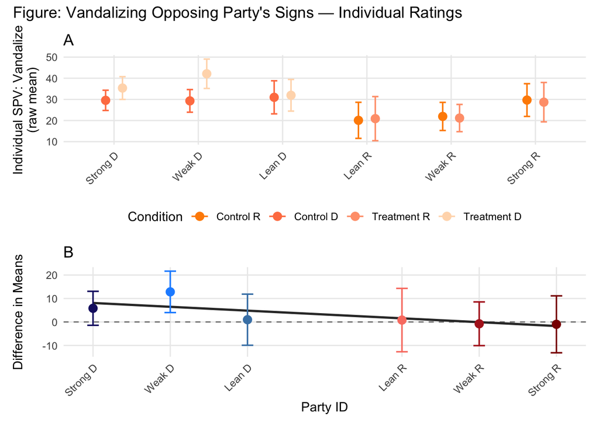

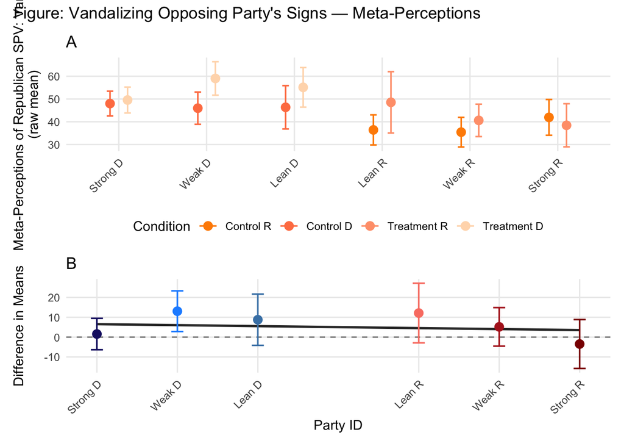

```r
vandalize_indiv_factor <- lm_robust(SPV_indiv_vandalize ~ condition_dummy * factor(party_numeric),
                                  data = data_clean, se_type = "HC2")
emm_vandalize_indiv_factor <- emmeans(vandalize_indiv_factor, ~ condition_dummy | party_numeric,
                                    vcov. = vcov(vandalize_indiv_factor))
contr_vandalize_indiv_factor_df <- confint(contrast(emm_vandalize_indiv_factor,
                                                  method = list("Treatment - Control" = c(-1, 1)),
                                                  by = "party_numeric")) |>
  as.data.frame() |>
  mutate(party_numeric = as.numeric(as.character(party_numeric)))

vandalize_meta_R_factor <- lm_robust(SPV_meta_vandalize ~ condition_dummy * factor(party_numeric),
                                   data = data_clean, se_type = "HC2")
emm_vandalize_meta_R_factor <- emmeans(vandalize_meta_R_factor, ~ condition_dummy | party_numeric,
                                     vcov. = vcov(vandalize_meta_R_factor))
contr_vandalize_meta_R_factor_df <- confint(contrast(emm_vandalize_meta_R_factor,
                                                   method = list("Treatment - Control" = c(-1, 1)),
                                                   by = "party_numeric")) |>
  as.data.frame() |>
  mutate(party_numeric = as.numeric(as.character(party_numeric)))

p_vandalize_indiv <- make_SPV_panels(
  "SPV_indiv_vandalize",
  contr_vandalize_indiv_partyaffil_df,
  contr_vandalize_indiv_factor_df,
  "Individual SPV: Vandalize\n(raw mean)",
  "Figure: Vandalizing Opposing Party's Signs — Individual Ratings",
  color_A = c("Control R" = "darkorange",  "Treatment R" = "lightsalmon",
              "Control D" = "coral",        "Treatment D" = "peachpuff"))

p_vandalize_meta_R <- make_SPV_panels(
  "SPV_meta_vandalize",
  contr_vandalize_meta_R_partyaffil_df,
  contr_vandalize_meta_R_factor_df,
  "Meta-Perceptions of Republican SPV: Vandalize\n(raw mean)",
  "Figure: Vandalizing Opposing Party's Signs — Meta-Perceptions",
  color_A = c("Control R" = "darkorange",  "Treatment R" = "lightsalmon",
              "Control D" = "coral",        "Treatment D" = "peachpuff"))
```

### Scenario: Messaging threats online to an out-party representative

#### Models

```r
# 1.1: form models for:
# A: Individual SPV (Aggregated)
lm_message_indiv <- lm_robust(SPV_indiv_message ~ condition_dummy * PID_dummy * PID_bin,
                              data = data_clean, se_type = "HC2")
# B: Meta-Perceptions of Republican SPV
lm_message_meta_R <- lm_robust(SPV_meta_message ~ condition_dummy * PID_dummy * PID_bin,
                               data = data_clean, se_type = "HC2")
# C: Individual SPV (Reps only)
lm_R_message <- lm_robust(spv_Rmessage ~ condition_dummy * PID_bin,
                          data = data_clean, se_type = "HC2")
# D: Individual SPV (Dems only)
lm_D_message <- lm_robust(spv_Dmessage ~ condition_dummy * PID_bin,
                          data = data_clean, se_type = "HC2")
```

Individual SPV

| term | estimate | std.error | statistic | p.value | conf.low | conf.high | df | outcome |
| --- | --- | --- | --- | --- | --- | --- | --- | --- |
| (Intercept) | 11.479 | 3.016 | 3.806 | 0.000 | 5.559 | 17.399 | 776 | SPV_indiv_message |
| condition_dummy | 9.043 | 5.074 | 1.782 | 0.075 | -0.917 | 19.004 | 776 | SPV_indiv_message |
| PID_dummy | -10.487 | 5.260 | -1.994 | 0.047 | -20.813 | -0.161 | 776 | SPV_indiv_message |
| PID_bin | 1.658 | 1.939 | 0.855 | 0.393 | -2.149 | 5.464 | 776 | SPV_indiv_message |
| condition_dummy:PID_dummy | -10.092 | 7.429 | -1.358 | 0.175 | -24.675 | 4.492 | 776 | SPV_indiv_message |
| condition_dummy:PID_bin | -4.948 | 3.103 | -1.595 | 0.111 | -11.039 | 1.142 | 776 | SPV_indiv_message |
| PID_dummy:PID_bin | 8.394 | 3.593 | 2.336 | 0.020 | 1.340 | 15.448 | 776 | SPV_indiv_message |
| condition_dummy:PID_dummy:PID_bin | 4.245 | 5.458 | 0.778 | 0.437 | -6.470 | 14.960 | 776 | SPV_indiv_message |

Meta-Perceptions Republican SPV

| term | estimate | std.error | statistic | p.value | conf.low | conf.high | df | outcome |
| --- | --- | --- | --- | --- | --- | --- | --- | --- |
| (Intercept) | 32.821 | 4.818 | 6.813 | 0.000 | 23.364 | 42.278 | 775 | SPV_meta_message |
| condition_dummy | 16.817 | 7.474 | 2.250 | 0.025 | 2.144 | 31.489 | 775 | SPV_meta_message |
| PID_dummy | -25.232 | 6.005 | -4.202 | 0.000 | -37.021 | -13.443 | 775 | SPV_meta_message |
| PID_bin | 0.340 | 2.940 | 0.116 | 0.908 | -5.432 | 6.112 | 775 | SPV_meta_message |
| condition_dummy:PID_dummy | 2.535 | 10.416 | 0.243 | 0.808 | -17.911 | 22.982 | 775 | SPV_meta_message |
| condition_dummy:PID_bin | -7.061 | 4.498 | -1.570 | 0.117 | -15.890 | 1.769 | 775 | SPV_meta_message |
| PID_dummy:PID_bin | 9.672 | 3.970 | 2.436 | 0.015 | 1.880 | 17.465 | 775 | SPV_meta_message |
| condition_dummy:PID_dummy:PID_bin | -3.328 | 6.882 | -0.484 | 0.629 | -16.837 | 10.180 | 775 | SPV_meta_message |

Individual SPV (Republicans Only)

| term | estimate | std.error | statistic | p.value | conf.low | conf.high | df | outcome |
| --- | --- | --- | --- | --- | --- | --- | --- | --- |
| (Intercept) | 0.992 | 4.310 | 0.230 | 0.818 | -7.496 | 9.480 | 254 | spv_Rmessage |
| condition_dummy | -1.048 | 5.426 | -0.193 | 0.847 | -11.735 | 9.638 | 254 | spv_Rmessage |
| PID_bin | 10.052 | 3.025 | 3.323 | 0.001 | 4.094 | 16.009 | 254 | spv_Rmessage |
| condition_dummy:PID_bin | -0.703 | 4.491 | -0.157 | 0.876 | -9.547 | 8.140 | 254 | spv_Rmessage |

Individual SPV (Democrats Only)

| term | estimate | std.error | statistic | p.value | conf.low | conf.high | df | outcome |
| --- | --- | --- | --- | --- | --- | --- | --- | --- |
| (Intercept) | 11.479 | 3.016 | 3.806 | 0.000 | 5.555 | 17.403 | 522 | spv_Dmessage |
| condition_dummy | 9.043 | 5.074 | 1.782 | 0.075 | -0.924 | 19.011 | 522 | spv_Dmessage |
| PID_bin | 1.658 | 1.939 | 0.855 | 0.393 | -2.152 | 5.467 | 522 | spv_Dmessage |
| condition_dummy:PID_bin | -4.948 | 3.103 | -1.595 | 0.111 | -11.044 | 1.147 | 522 | spv_Dmessage |

#### Party ID (Dummy)

```r
# form emmeans and contrast matrices for Individual SPV (Aggregated)
emm_message_indiv <- emmeans(lm_message_indiv, ~ condition_dummy * PID_dummy,
                             vcov. = vcov(lm_message_indiv))
emm_message_indiv_df <- as.data.frame(confint(emm_message_indiv)) %>%
  mutate(
    condition_dummy = factor(condition_dummy, levels = c(0, 1),
                             labels = c("Control", "Treatment")),
    PID_dummy = factor(PID_dummy, levels = c(0, 1),
                       labels = c("Democrat", "Republican")),
    group = interaction(condition_dummy, PID_dummy))
contr_message_indiv <- contrast(emm_message_indiv,
                                method = list(
                                  "Control D vs. Control R"     = c(-1,  0,  1,  0),
                                  "Control D vs. Treatment D"   = c(-1,  1,  0,  0),
                                  "Control R vs. Treatment R"   = c( 0,  0, -1,  1),
                                  "Treatment D vs. Treatment R" = c( 0, -1,  0,  1)))
contr_message_indiv_df <- as.data.frame(confint(contr_message_indiv))
contr_table_message_indiv <- summary(contr_message_indiv) |>
  as.data.frame() |>
  dplyr::select(contrast, estimate, SE, df, t.ratio, p.value)
```

| contrast | estimate | SE | df | t.ratio | p.value |
| --- | --- | --- | --- | --- | --- |
| Control D vs. Control R | 2.162887 | 2.665734 | 776 | 0.8113664 | 0.4174041 |
| Control D vs. Treatment D | 1.586123 | 2.048571 | 776 | 0.7742580 | 0.4390141 |
| Control R vs. Treatment R | -2.108281 | 3.401649 | 776 | -0.6197822 | 0.5355832 |
| Treatment D vs. Treatment R | -1.531517 | 2.943080 | 776 | -0.5203789 | 0.6029480 |

```r
# form emmeans and contrast matrices for Meta-Perceptions of Republican SPV
emm_message_meta_R <- emmeans(lm_message_meta_R, ~ condition_dummy * PID_dummy,
                              vcov. = vcov(lm_message_meta_R))
emm_message_meta_R_df <- as.data.frame(confint(emm_message_meta_R)) %>%
  mutate(
    condition_dummy = factor(condition_dummy, levels = c(0, 1),
                             labels = c("Control", "Treatment")),
    PID_dummy = factor(PID_dummy, levels = c(0, 1),
                       labels = c("Democrat", "Republican")),
    group = interaction(condition_dummy, PID_dummy))
contr_message_meta_R <- contrast(emm_message_meta_R,
                                 method = list(
                                   "Control D vs. Control R"     = c(-1,  0,  1,  0),
                                   "Control D vs. Treatment D"   = c(-1,  1,  0,  0),
                                   "Control R vs. Treatment R"   = c( 0,  0, -1,  1),
                                   "Treatment D vs. Treatment R" = c( 0, -1,  0,  1)))
contr_message_meta_R_df <- as.data.frame(confint(contr_message_meta_R))
contr_table_message_meta_R <- summary(contr_message_meta_R) |>
  as.data.frame() |>
  dplyr::select(contrast, estimate, SE, df, t.ratio, p.value)
```

| contrast | estimate | SE | df | t.ratio | p.value |
| --- | --- | --- | --- | --- | --- |
| Control D vs. Control R | -10.656018 | 2.905269 | 775 | -3.667825 | 0.0002613 |
| Control D vs. Treatment D | 6.176294 | 2.905850 | 775 | 2.125469 | 0.0338632 |
| Control R vs. Treatment R | 3.695746 | 3.556667 | 775 | 1.039104 | 0.2990806 |
| Treatment D vs. Treatment R | -13.136567 | 3.557142 | 775 | -3.693012 | 0.0002372 |

#### Party ID (7-pt)

```r
# form emmeans and contrast matrices for Individual SPV (Aggregated)
message_indiv_partyaffil <- lm_robust(SPV_indiv_message ~ condition_dummy * party_numeric, data = data_clean, se_type = "HC2")
emm_message_indiv_partyaffil<- emmeans(message_indiv_partyaffil, ~ condition_dummy * party_numeric,
                                       at = list(party_numeric = c(1, 2, 3, 5, 6, 7)),
                                       vcov. = vcov(message_indiv_partyaffil))
contr_message_indiv_partyaffil<- contrast(emm_message_indiv_partyaffil,
                                          method = list("Treatment - Control" = c(-1, 1)),
                                          by = "party_numeric")
contr_message_indiv_partyaffil_df <- confint(contr_message_indiv_partyaffil) |>
  as.data.frame() |>
  mutate(
    party_label = factor(party_numeric, levels = c(1, 2, 3, 5, 6, 7),
                         labels = c("Strong D","Weak D","Lean D","Lean R","Weak R","Strong R")),
    model = "Individual Ratings")
```

| contrast | party_numeric | estimate | SE | df | lower.CL | upper.CL | party_label | model |
| --- | --- | --- | --- | --- | --- | --- | --- | --- |
| Treatment - Control | 1 | 1.4912600 | 2.324198 | 784 | -3.071128 | 6.053648 | Strong D | Individual Ratings |
| Treatment - Control | 2 | 0.7895172 | 1.870194 | 784 | -2.881664 | 4.460698 | Weak D | Individual Ratings |
| Treatment - Control | 3 | 0.0877744 | 1.734743 | 784 | -3.317516 | 3.493065 | Lean D | Individual Ratings |
| Treatment - Control | 5 | -1.3157113 | 2.506126 | 784 | -6.235223 | 3.603801 | Lean R | Individual Ratings |
| Treatment - Control | 6 | -2.0174541 | 3.168643 | 784 | -8.237483 | 4.202575 | Weak R | Individual Ratings |
| Treatment - Control | 7 | -2.7191969 | 3.900757 | 784 | -10.376361 | 4.937967 | Strong R | Individual Ratings |

```r
# form emmeans and contrast matrices for Meta-Perceptions of Republican SPV
message_meta_R_partyaffil <- lm_robust(SPV_meta_message ~ condition_dummy * party_numeric, data = data_clean, se_type = "HC2")
emm_message_meta_R_partyaffil<- emmeans(message_meta_R_partyaffil, ~ condition_dummy * party_numeric,
                                        at = list(party_numeric = c(1, 2, 3, 5, 6, 7)),
                                        vcov. = vcov(message_meta_R_partyaffil))
contr_message_meta_R_partyaffil<- contrast(emm_message_meta_R_partyaffil,
                                           method = list("Treatment - Control" = c(-1, 1)),
                                           by = "party_numeric")
contr_message_meta_R_partyaffil_df <- confint(contr_message_meta_R_partyaffil) |>
  as.data.frame() |>
  mutate(
    party_label = factor(party_numeric, levels = c(1, 2, 3, 5, 6, 7),
                         labels = c("Strong D","Weak D","Lean D","Lean R","Weak R","Strong R")),
    model = "Meta-Perceptions of Republicans' Ratings")
```

| contrast | party_numeric | estimate | SE | df | lower.CL | upper.CL | party_label | model |
| --- | --- | --- | --- | --- | --- | --- | --- | --- |
| Treatment - Control | 1 | 5.807870 | 3.289241 | 783 | -0.6489039 | 12.264644 | Strong D | Meta-Perceptions of Republicans’ Ratings |
| Treatment - Control | 2 | 5.593071 | 2.658699 | 783 | 0.3740494 | 10.812093 | Weak D | Meta-Perceptions of Republicans’ Ratings |
| Treatment - Control | 3 | 5.378273 | 2.285402 | 783 | 0.8920331 | 9.864513 | Lean D | Meta-Perceptions of Republicans’ Ratings |
| Treatment - Control | 5 | 4.948676 | 2.691882 | 783 | -0.3354840 | 10.232836 | Lean R | Meta-Perceptions of Republicans’ Ratings |
| Treatment - Control | 6 | 4.733878 | 3.333919 | 783 | -1.8106001 | 11.278356 | Weak R | Meta-Perceptions of Republicans’ Ratings |
| Treatment - Control | 7 | 4.519079 | 4.109575 | 783 | -3.5480098 | 12.586169 | Strong R | Meta-Perceptions of Republicans’ Ratings |

#### Party ID (7-pt) + Partisan Self-Concept

```r
lm_message_indiv_R_7 <- lm_robust(SPV_indiv_message ~ condition_dummy * party_numeric * PID_bin,
                                  data = data_clean, se_type = "HC2")
emm_message_indiv_R_7<- emmeans(lm_message_indiv_R_7, ~ condition_dummy | party_numeric,
                                at = list(party_numeric = c(1, 2, 3, 5, 6, 7)),
                                vcov. = vcov(lm_message_indiv_R_7))
contr_message_indiv_R_7<- contrast(emm_message_indiv_R_7,
                                   method = list("Treatment - Control" = c(-1, 1)),
                                   by = "party_numeric")
contr_message_indiv_R_7_df <- as.data.frame(confint(contr_message_indiv_R_7))
contr_table_message_indiv_R_7_df <- summary(contr_message_indiv_R_7) |>
  as.data.frame() |>
  dplyr::select(contrast, party_numeric, estimate, SE, df, t.ratio, p.value) |>
  mutate(party_label = factor(party_numeric, levels = c(1, 2, 3, 5, 6, 7),
                              labels = c("Strong D","Weak D","Lean D","Lean R","Weak R","Strong R")))
```

| contrast | party_numeric | estimate | SE | df | t.ratio | p.value | party_label |
| --- | --- | --- | --- | --- | --- | --- | --- |
| Treatment - Control | 1 | 2.4302838 | 2.392370 | 776 | 1.0158477 | 0.3100185 | Strong D |
| Treatment - Control | 2 | 1.5926309 | 1.961566 | 776 | 0.8119181 | 0.4170876 | Weak D |
| Treatment - Control | 3 | 0.7549779 | 1.804752 | 776 | 0.4183277 | 0.6758233 | Lean D |
| Treatment - Control | 5 | -0.9203281 | 2.435399 | 776 | -0.3778961 | 0.7056111 | Lean R |
| Treatment - Control | 6 | -1.7579810 | 3.032461 | 776 | -0.5797209 | 0.5622711 | Weak R |
| Treatment - Control | 7 | -2.5956340 | 3.707500 | 776 | -0.7001037 | 0.4840724 | Strong R |

```r
lm_message_meta_R_7 <- lm_robust(SPV_meta_message ~ condition_dummy * party_numeric * PID_bin,
                                 data = data_clean, se_type = "HC2")
emm_message_meta_R_7<- emmeans(lm_message_meta_R_7, ~ condition_dummy | party_numeric,
                               at = list(party_numeric = c(1, 2, 3, 5, 6, 7)),
                               vcov. = vcov(lm_message_meta_R_7))
contr_message_meta_R_7<- contrast(emm_message_meta_R_7,
                                  method = list("Treatment - Control" = c(-1, 1)),
                                  by = "party_numeric")
contr_message_meta_R_7_df <- as.data.frame(confint(contr_message_meta_R_7))
contr_table_message_meta_R_7_df <- summary(contr_message_meta_R_7) |>
  as.data.frame() |>
  dplyr::select(contrast, party_numeric, estimate, SE, df, t.ratio, p.value) |>
  mutate(party_label = factor(party_numeric, levels = c(1, 2, 3, 5, 6, 7),
                              labels = c("Strong D","Weak D","Lean D","Lean R","Weak R","Strong R")))
```

| contrast | party_numeric | estimate | SE | df | t.ratio | p.value | party_label |
| --- | --- | --- | --- | --- | --- | --- | --- |
| Treatment - Control | 1 | 6.025631 | 3.479417 | 775 | 1.731793 | 0.0837083 | Strong D |
| Treatment - Control | 2 | 5.814006 | 2.800035 | 775 | 2.076405 | 0.0381856 | Weak D |
| Treatment - Control | 3 | 5.602382 | 2.355789 | 775 | 2.378134 | 0.0176420 | Lean D |
| Treatment - Control | 5 | 5.179133 | 2.626008 | 775 | 1.972246 | 0.0489367 | Lean R |
| Treatment - Control | 6 | 4.967509 | 3.245389 | 775 | 1.530636 | 0.1262675 | Weak R |
| Treatment - Control | 7 | 4.755884 | 4.018068 | 775 | 1.183625 | 0.2369246 | Strong R |

#### Factor models for panel plots

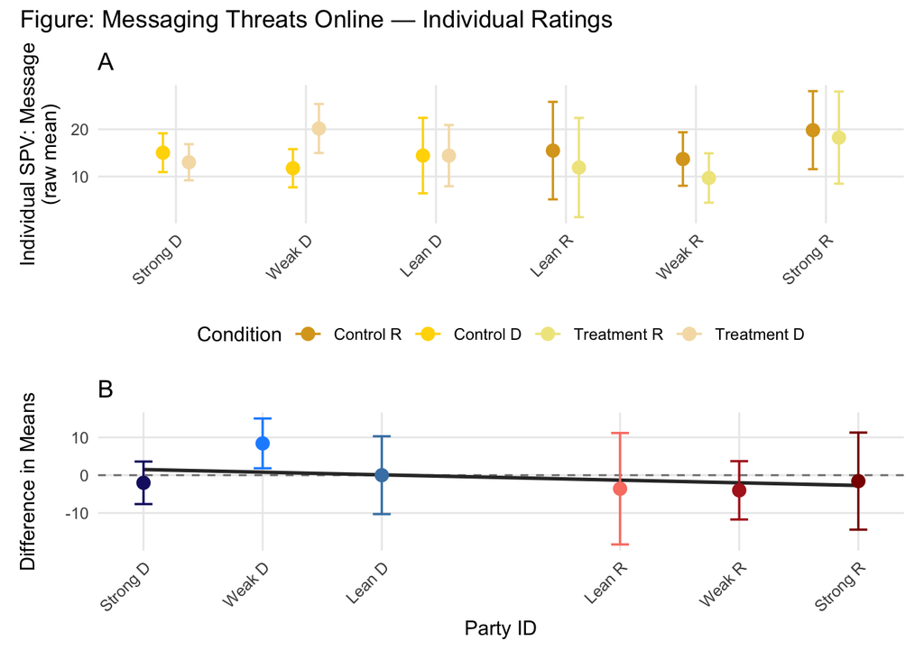

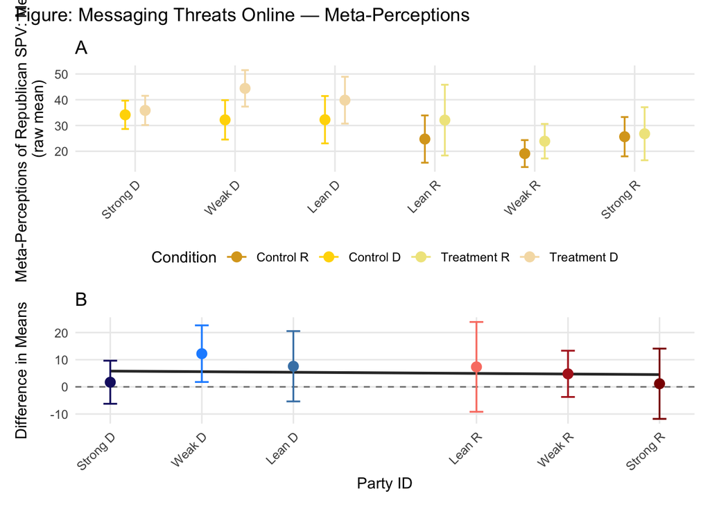

```r
message_indiv_factor <- lm_robust(SPV_indiv_message ~ condition_dummy * factor(party_numeric),
                                  data = data_clean, se_type = "HC2")
emm_message_indiv_factor <- emmeans(message_indiv_factor, ~ condition_dummy | party_numeric,
                                    vcov. = vcov(message_indiv_factor))
contr_message_indiv_factor_df <- confint(contrast(emm_message_indiv_factor,
                                                  method = list("Treatment - Control" = c(-1, 1)),
                                                  by = "party_numeric")) |>
  as.data.frame() |>
  mutate(party_numeric = as.numeric(as.character(party_numeric)))

message_meta_R_factor <- lm_robust(SPV_meta_message ~ condition_dummy * factor(party_numeric),
                                   data = data_clean, se_type = "HC2")
emm_message_meta_R_factor <- emmeans(message_meta_R_factor, ~ condition_dummy | party_numeric,
                                     vcov. = vcov(message_meta_R_factor))
contr_message_meta_R_factor_df <- confint(contrast(emm_message_meta_R_factor,
                                                   method = list("Treatment - Control" = c(-1, 1)),
                                                   by = "party_numeric")) |>
  as.data.frame() |>
  mutate(party_numeric = as.numeric(as.character(party_numeric)))

p_message_indiv <- make_SPV_panels(
  "SPV_indiv_message",
  contr_message_indiv_partyaffil_df,
  contr_message_indiv_factor_df,
  "Individual SPV: Message\n(raw mean)",
  "Figure: Messaging Threats Online — Individual Ratings",
  color_A = c("Control R" = "goldenrod", "Treatment R" = "khaki",
              "Control D" = "gold",       "Treatment D" = "wheat"))

p_message_meta_R <- make_SPV_panels(
  "SPV_meta_message",
  contr_message_meta_R_partyaffil_df,
  contr_message_meta_R_factor_df,
  "Meta-Perceptions of Republican SPV: Message\n(raw mean)",
  "Figure: Messaging Threats Online — Meta-Perceptions",
  color_A = c("Control R" = "goldenrod", "Treatment R" = "khaki",
              "Control D" = "gold",       "Treatment D" = "wheat"))
```

### Scenario: Physically assaulting an out-party member

#### Models

```r
# 1.1: form models for:
# A: Individual SPV (Aggregated)
lm_assault_indiv <- lm_robust(SPV_indiv_assault ~ condition_dummy * PID_dummy * PID_bin,
                              data = data_clean, se_type = "HC2")
# B: Meta-Perceptions of Republican SPV
lm_assault_meta_R <- lm_robust(SPV_meta_assault ~ condition_dummy * PID_dummy * PID_bin,
                               data = data_clean, se_type = "HC2")
# C: Individual SPV (Reps only)
lm_R_assault <- lm_robust(spv_Rassault ~ condition_dummy * PID_bin,
                          data = data_clean, se_type = "HC2")
# D: Individual SPV (Dems only)
lm_D_assault <- lm_robust(spv_Dassault ~ condition_dummy * PID_bin,
                          data = data_clean, se_type = "HC2")
```

Individual SPV

| term | estimate | std.error | statistic | p.value | conf.low | conf.high | df | outcome |
| --- | --- | --- | --- | --- | --- | --- | --- | --- |
| (Intercept) | 9.179 | 2.423 | 3.788 | 0.000 | 4.422 | 13.936 | 776 | SPV_indiv_assault |
| condition_dummy | 10.027 | 4.814 | 2.083 | 0.038 | 0.577 | 19.476 | 776 | SPV_indiv_assault |
| PID_dummy | -12.890 | 3.770 | -3.419 | 0.001 | -20.291 | -5.489 | 776 | SPV_indiv_assault |
| PID_bin | 1.572 | 1.618 | 0.972 | 0.331 | -1.603 | 4.748 | 776 | SPV_indiv_assault |
| condition_dummy:PID_dummy | -8.759 | 6.489 | -1.350 | 0.177 | -21.498 | 3.980 | 776 | SPV_indiv_assault |
| condition_dummy:PID_bin | -5.673 | 2.875 | -1.973 | 0.049 | -11.316 | -0.029 | 776 | SPV_indiv_assault |
| PID_dummy:PID_bin | 10.652 | 3.038 | 3.506 | 0.000 | 4.687 | 16.616 | 776 | SPV_indiv_assault |
| condition_dummy:PID_dummy:PID_bin | 4.767 | 5.008 | 0.952 | 0.341 | -5.063 | 14.597 | 776 | SPV_indiv_assault |

Meta-Perceptions Republican SPV

| term | estimate | std.error | statistic | p.value | conf.low | conf.high | df | outcome |
| --- | --- | --- | --- | --- | --- | --- | --- | --- |
| (Intercept) | 32.391 | 4.947 | 6.548 | 0.000 | 22.681 | 42.102 | 776 | SPV_meta_assault |
| condition_dummy | 18.053 | 7.672 | 2.353 | 0.019 | 2.991 | 33.114 | 776 | SPV_meta_assault |
| PID_dummy | -32.920 | 5.765 | -5.711 | 0.000 | -44.237 | -21.604 | 776 | SPV_meta_assault |
| PID_bin | 0.344 | 3.010 | 0.114 | 0.909 | -5.565 | 6.252 | 776 | SPV_meta_assault |
| condition_dummy:PID_dummy | 7.925 | 10.202 | 0.777 | 0.438 | -12.101 | 27.951 | 776 | SPV_meta_assault |
| condition_dummy:PID_bin | -7.579 | 4.616 | -1.642 | 0.101 | -16.641 | 1.483 | 776 | SPV_meta_assault |
| PID_dummy:PID_bin | 14.458 | 3.898 | 3.709 | 0.000 | 6.805 | 22.111 | 776 | SPV_meta_assault |
| condition_dummy:PID_dummy:PID_bin | -7.131 | 6.747 | -1.057 | 0.291 | -20.376 | 6.114 | 776 | SPV_meta_assault |

Individual SPV (Republicans Only)

| term | estimate | std.error | statistic | p.value | conf.low | conf.high | df | outcome |
| --- | --- | --- | --- | --- | --- | --- | --- | --- |
| (Intercept) | -3.711 | 2.888 | -1.285 | 0.200 | -9.399 | 1.976 | 254 | spv_Rassault |
| condition_dummy | 1.268 | 4.352 | 0.291 | 0.771 | -7.303 | 9.838 | 254 | spv_Rassault |
| PID_bin | 12.224 | 2.572 | 4.753 | 0.000 | 7.159 | 17.289 | 254 | spv_Rassault |
| condition_dummy:PID_bin | -0.906 | 4.100 | -0.221 | 0.825 | -8.981 | 7.169 | 254 | spv_Rassault |

Individual SPV (Democrats Only)

| term | estimate | std.error | statistic | p.value | conf.low | conf.high | df | outcome |
| --- | --- | --- | --- | --- | --- | --- | --- | --- |
| (Intercept) | 9.179 | 2.423 | 3.788 | 0.000 | 4.418 | 13.940 | 522 | spv_Dassault |
| condition_dummy | 10.027 | 4.814 | 2.083 | 0.038 | 0.570 | 19.484 | 522 | spv_Dassault |
| PID_bin | 1.572 | 1.618 | 0.972 | 0.331 | -1.605 | 4.750 | 522 | spv_Dassault |
| condition_dummy:PID_bin | -5.673 | 2.875 | -1.973 | 0.049 | -11.320 | -0.025 | 522 | spv_Dassault |

#### Party ID (Dummy)

```r
# form emmeans and contrast matrices for Individual SPV (Aggregated)
emm_assault_indiv <- emmeans(lm_assault_indiv, ~ condition_dummy * PID_dummy,
                             vcov. = vcov(lm_assault_indiv))
emm_assault_indiv_df <- as.data.frame(confint(emm_assault_indiv)) %>%
  mutate(
    condition_dummy = factor(condition_dummy, levels = c(0, 1),
                             labels = c("Control", "Treatment")),
    PID_dummy = factor(PID_dummy, levels = c(0, 1),
                       labels = c("Democrat", "Republican")),
    group = interaction(condition_dummy, PID_dummy))
contr_assault_indiv <- contrast(emm_assault_indiv,
                                method = list(
                                  "Control D vs. Control R"     = c(-1,  0,  1,  0),
                                  "Control D vs. Treatment D"   = c(-1,  1,  0,  0),
                                  "Control R vs. Treatment R"   = c( 0,  0, -1,  1),
                                  "Treatment D vs. Treatment R" = c( 0, -1,  0,  1)))
contr_assault_indiv_df <- as.data.frame(confint(contr_assault_indiv))
contr_table_assault_indiv <- summary(contr_assault_indiv) |>
  as.data.frame() |>
  dplyr::select(contrast, estimate, SE, df, t.ratio, p.value)
```

| contrast | estimate | SE | df | t.ratio | p.value |
| --- | --- | --- | --- | --- | --- |
| Control D vs. Control R | 3.161920 | 2.421940 | 776 | 1.3055317 | 0.1920988 |
| Control D vs. Treatment D | 1.477989 | 1.862313 | 776 | 0.7936311 | 0.4276528 |
| Control R vs. Treatment R | -0.097438 | 3.235799 | 776 | -0.0301125 | 0.9759851 |
| Treatment D vs. Treatment R | 1.586492 | 2.841269 | 776 | 0.5583746 | 0.5767497 |

```r
# form emmeans and contrast matrices for Meta-Perceptions of Republican SPV
emm_assault_meta_R <- emmeans(lm_assault_meta_R, ~ condition_dummy * PID_dummy,
                              vcov. = vcov(lm_assault_meta_R))
emm_assault_meta_R_df <- as.data.frame(confint(emm_assault_meta_R)) %>%
  mutate(
    condition_dummy = factor(condition_dummy, levels = c(0, 1),
                             labels = c("Control", "Treatment")),
    PID_dummy = factor(PID_dummy, levels = c(0, 1),
                       labels = c("Democrat", "Republican")),
    group = interaction(condition_dummy, PID_dummy))
contr_assault_meta_R <- contrast(emm_assault_meta_R,
                                 method = list(
                                   "Control D vs. Control R"     = c(-1,  0,  1,  0),
                                   "Control D vs. Treatment D"   = c(-1,  1,  0,  0),
                                   "Control R vs. Treatment R"   = c( 0,  0, -1,  1),
                                   "Treatment D vs. Treatment R" = c( 0, -1,  0,  1)))
contr_assault_meta_R_df <- as.data.frame(confint(contr_assault_meta_R))
contr_table_assault_meta_R <- summary(contr_assault_meta_R) |>
  as.data.frame() |>
  dplyr::select(contrast, estimate, SE, df, t.ratio, p.value)
```

| contrast | estimate | SE | df | t.ratio | p.value |
| --- | --- | --- | --- | --- | --- |
| Control D vs. Control R | -11.131716 | 2.804346 | 776 | -3.969451 | 0.0000787 |
| Control D vs. Treatment D | 6.631068 | 2.886408 | 776 | 2.297343 | 0.0218646 |
| Control R vs. Treatment R | 3.809534 | 3.341862 | 776 | 1.139943 | 0.2546615 |
| Treatment D vs. Treatment R | -13.953250 | 3.411016 | 776 | -4.090643 | 0.0000475 |

#### Party ID (7-pt)

```r
# form emmeans and contrast matrices for Individual SPV (Aggregated)
assault_indiv_partyaffil <- lm_robust(SPV_indiv_assault ~ condition_dummy * party_numeric, data = data_clean, se_type = "HC2")
emm_assault_indiv_partyaffil<- emmeans(assault_indiv_partyaffil, ~ condition_dummy * party_numeric,
                                       at = list(party_numeric = c(1, 2, 3, 5, 6, 7)),
                                       vcov. = vcov(assault_indiv_partyaffil))
contr_assault_indiv_partyaffil<- contrast(emm_assault_indiv_partyaffil,
                                          method = list("Treatment - Control" = c(-1, 1)),
                                          by = "party_numeric")
contr_assault_indiv_partyaffil_df <- confint(contr_assault_indiv_partyaffil) |>
  as.data.frame() |>
  mutate(
    party_label = factor(party_numeric, levels = c(1, 2, 3, 5, 6, 7),
                         labels = c("Strong D","Weak D","Lean D","Lean R","Weak R","Strong R")),
    model = "Individual Ratings")
```

| contrast | party_numeric | estimate | SE | df | lower.CL | upper.CL | party_label | model |
| --- | --- | --- | --- | --- | --- | --- | --- | --- |
| Treatment - Control | 1 | 0.8867638 | 2.117820 | 784 | -3.270506 | 5.044033 | Strong D | Individual Ratings |
| Treatment - Control | 2 | 0.7101517 | 1.697449 | 784 | -2.621932 | 4.042235 | Weak D | Individual Ratings |
| Treatment - Control | 3 | 0.5335396 | 1.602081 | 784 | -2.611337 | 3.678416 | Lean D | Individual Ratings |
| Treatment - Control | 5 | 0.1803155 | 2.409315 | 784 | -4.549156 | 4.909787 | Lean R | Individual Ratings |
| Treatment - Control | 6 | 0.0037034 | 3.059020 | 784 | -6.001136 | 6.008542 | Weak R | Individual Ratings |
| Treatment - Control | 7 | -0.1729087 | 3.768231 | 784 | -7.569925 | 7.224108 | Strong R | Individual Ratings |

```r
# form emmeans and contrast matrices for Meta-Perceptions of Republican SPV
assault_meta_R_partyaffil <- lm_robust(SPV_meta_assault ~ condition_dummy * party_numeric, data = data_clean, se_type = "HC2")
emm_assault_meta_R_partyaffil<- emmeans(assault_meta_R_partyaffil, ~ condition_dummy * party_numeric,
                                        at = list(party_numeric = c(1, 2, 3, 5, 6, 7)),
                                        vcov. = vcov(assault_meta_R_partyaffil))
contr_assault_meta_R_partyaffil<- contrast(emm_assault_meta_R_partyaffil,
                                           method = list("Treatment - Control" = c(-1, 1)),
                                           by = "party_numeric")
contr_assault_meta_R_partyaffil_df <- confint(contr_assault_meta_R_partyaffil) |>
  as.data.frame() |>
  mutate(
    party_label = factor(party_numeric, levels = c(1, 2, 3, 5, 6, 7),
                         labels = c("Strong D","Weak D","Lean D","Lean R","Weak R","Strong R")),
    model = "Meta-Perceptions of Republicans' Ratings")
```

| contrast | party_numeric | estimate | SE | df | lower.CL | upper.CL | party_label | model |
| --- | --- | --- | --- | --- | --- | --- | --- | --- |
| Treatment - Control | 1 | 6.562129 | 3.253665 | 784 | 0.1752020 | 12.94906 | Strong D | Meta-Perceptions of Republicans’ Ratings |
| Treatment - Control | 2 | 6.167428 | 2.634814 | 784 | 0.9953029 | 11.33955 | Weak D | Meta-Perceptions of Republicans’ Ratings |
| Treatment - Control | 3 | 5.772727 | 2.257687 | 784 | 1.3408998 | 10.20455 | Lean D | Meta-Perceptions of Republicans’ Ratings |
| Treatment - Control | 5 | 4.983325 | 2.608441 | 784 | -0.1370299 | 10.10368 | Lean R | Meta-Perceptions of Republicans’ Ratings |
| Treatment - Control | 6 | 4.588624 | 3.218054 | 784 | -1.7283977 | 10.90565 | Weak R | Meta-Perceptions of Republicans’ Ratings |
| Treatment - Control | 7 | 4.193923 | 3.963178 | 784 | -3.5857725 | 11.97362 | Strong R | Meta-Perceptions of Republicans’ Ratings |

#### Party ID (7-pt) + Partisan Self-Concept

```r
lm_assault_indiv_R_7 <- lm_robust(SPV_indiv_assault ~ condition_dummy * party_numeric * PID_bin,
                                  data = data_clean, se_type = "HC2")
emm_assault_indiv_R_7<- emmeans(lm_assault_indiv_R_7, ~ condition_dummy | party_numeric,
                                at = list(party_numeric = c(1, 2, 3, 5, 6, 7)),
                                vcov. = vcov(lm_assault_indiv_R_7))
contr_assault_indiv_R_7<- contrast(emm_assault_indiv_R_7,
                                   method = list("Treatment - Control" = c(-1, 1)),
                                   by = "party_numeric")
contr_assault_indiv_R_7_df <- as.data.frame(confint(contr_assault_indiv_R_7))
contr_table_assault_indiv_R_7_df <- summary(contr_assault_indiv_R_7) |>
  as.data.frame() |>
  dplyr::select(contrast, party_numeric, estimate, SE, df, t.ratio, p.value) |>
  mutate(party_label = factor(party_numeric, levels = c(1, 2, 3, 5, 6, 7),
                              labels = c("Strong D","Weak D","Lean D","Lean R","Weak R","Strong R")))
```

| contrast | party_numeric | estimate | SE | df | t.ratio | p.value | party_label |
| --- | --- | --- | --- | --- | --- | --- | --- |
| Treatment - Control | 1 | 1.7998829 | 2.238053 | 776 | 0.8042181 | 0.4215173 | Strong D |
| Treatment - Control | 2 | 1.5032622 | 1.829128 | 776 | 0.8218464 | 0.4114168 | Weak D |
| Treatment - Control | 3 | 1.2066415 | 1.683575 | 776 | 0.7167137 | 0.4737664 | Lean D |
| Treatment - Control | 5 | 0.6134002 | 2.295110 | 776 | 0.2672640 | 0.7893369 | Lean R |
| Treatment - Control | 6 | 0.3167795 | 2.865644 | 776 | 0.1105439 | 0.9120066 | Weak R |
| Treatment - Control | 7 | 0.0201588 | 3.508303 | 776 | 0.0057460 | 0.9954168 | Strong R |

```r
lm_assault_meta_R_7 <- lm_robust(SPV_meta_assault ~ condition_dummy * party_numeric * PID_bin,
                                 data = data_clean, se_type = "HC2")
emm_assault_meta_R_7<- emmeans(lm_assault_meta_R_7, ~ condition_dummy | party_numeric,
                               at = list(party_numeric = c(1, 2, 3, 5, 6, 7)),
                               vcov. = vcov(lm_assault_meta_R_7))
contr_assault_meta_R_7<- contrast(emm_assault_meta_R_7,
                                  method = list("Treatment - Control" = c(-1, 1)),
                                  by = "party_numeric")
contr_assault_meta_R_7_df <- as.data.frame(confint(contr_assault_meta_R_7))
contr_table_assault_meta_R_7_df <- summary(contr_assault_meta_R_7) |>
  as.data.frame() |>
  dplyr::select(contrast, party_numeric, estimate, SE, df, t.ratio, p.value) |>
  mutate(party_label = factor(party_numeric, levels = c(1, 2, 3, 5, 6, 7),
                              labels = c("Strong D","Weak D","Lean D","Lean R","Weak R","Strong R")))
```

| contrast | party_numeric | estimate | SE | df | t.ratio | p.value | party_label |
| --- | --- | --- | --- | --- | --- | --- | --- |
| Treatment - Control | 1 | 6.604987 | 3.443888 | 776 | 1.917887 | 0.0554921 | Strong D |
| Treatment - Control | 2 | 6.283123 | 2.774568 | 776 | 2.264541 | 0.0238159 | Weak D |
| Treatment - Control | 3 | 5.961260 | 2.317901 | 776 | 2.571836 | 0.0103011 | Lean D |
| Treatment - Control | 5 | 5.317533 | 2.496252 | 776 | 2.130207 | 0.0334685 | Lean R |
| Treatment - Control | 6 | 4.995669 | 3.068459 | 776 | 1.628071 | 0.1039157 | Weak R |
| Treatment - Control | 7 | 4.673806 | 3.799498 | 776 | 1.230111 | 0.2190282 | Strong R |

#### Factor models for panel plots

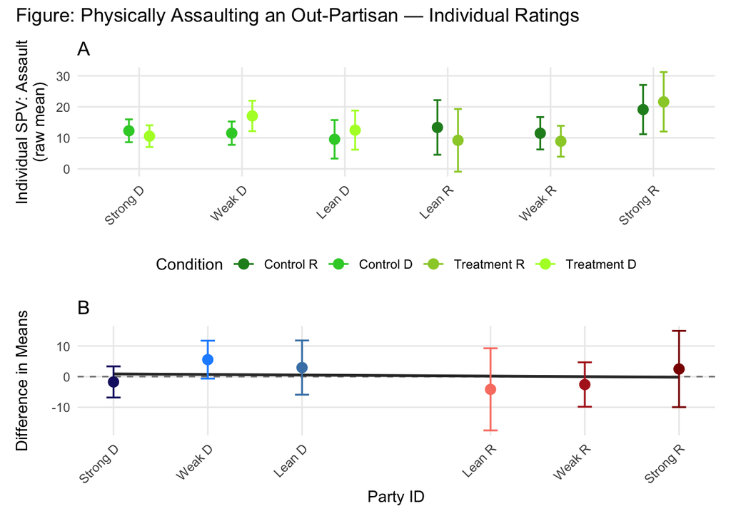

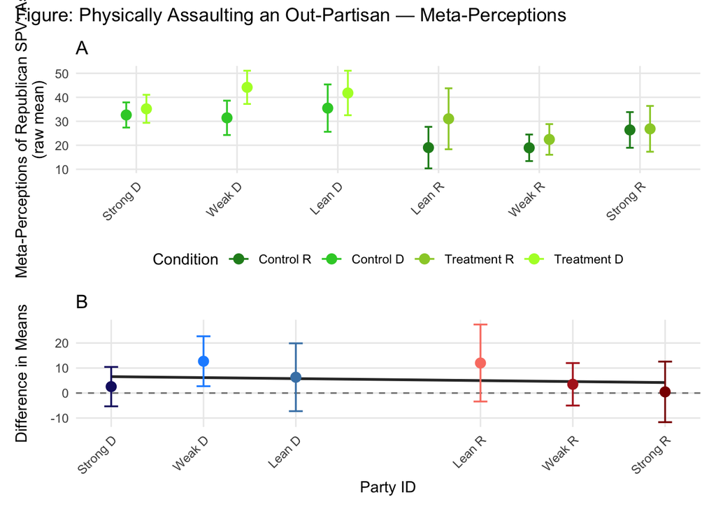

```r
assault_indiv_factor <- lm_robust(SPV_indiv_assault ~ condition_dummy * factor(party_numeric),
                                  data = data_clean, se_type = "HC2")
emm_assault_indiv_factor <- emmeans(assault_indiv_factor, ~ condition_dummy | party_numeric,
                                    vcov. = vcov(assault_indiv_factor))
contr_assault_indiv_factor_df <- confint(contrast(emm_assault_indiv_factor,
                                                  method = list("Treatment - Control" = c(-1, 1)),
                                                  by = "party_numeric")) |>
  as.data.frame() |>
  mutate(party_numeric = as.numeric(as.character(party_numeric)))

assault_meta_R_factor <- lm_robust(SPV_meta_assault ~ condition_dummy * factor(party_numeric),
                                   data = data_clean, se_type = "HC2")
emm_assault_meta_R_factor <- emmeans(assault_meta_R_factor, ~ condition_dummy | party_numeric,
                                     vcov. = vcov(assault_meta_R_factor))
contr_assault_meta_R_factor_df <- confint(contrast(emm_assault_meta_R_factor,
                                                   method = list("Treatment - Control" = c(-1, 1)),
                                                   by = "party_numeric")) |>
  as.data.frame() |>
  mutate(party_numeric = as.numeric(as.character(party_numeric)))

p_assault_indiv <- make_SPV_panels(
  "SPV_indiv_assault",
  contr_assault_indiv_partyaffil_df,
  contr_assault_indiv_factor_df,
  "Individual SPV: Assault\n(raw mean)",
  "Figure: Physically Assaulting an Out-Partisan — Individual Ratings",
  color_A = c("Control R" = "forestgreen", "Treatment R" = "yellowgreen",
              "Control D" = "limegreen",    "Treatment D" = "greenyellow"))

p_assault_meta_R <- make_SPV_panels(
  "SPV_meta_assault",
  contr_assault_meta_R_partyaffil_df,
  contr_assault_meta_R_factor_df,
  "Meta-Perceptions of Republican SPV: Assault\n(raw mean)",
  "Figure: Physically Assaulting an Out-Partisan — Meta-Perceptions",
  color_A = c("Control R" = "forestgreen", "Treatment R" = "yellowgreen",
              "Control D" = "limegreen",    "Treatment D" = "greenyellow"))
```

### Scenario: To achieve political goals

#### Models

```r
# 1.1: form models for:
# A: Individual SPV (Aggregated)
lm_justify_indiv <- lm_robust(SPV_indiv_justify ~ condition_dummy * PID_dummy * PID_bin,
                              data = data_clean, se_type = "HC2")
# B: Meta-Perceptions of Republican SPV
lm_justify_meta_R <- lm_robust(SPV_meta_justify ~ condition_dummy * PID_dummy * PID_bin,
                               data = data_clean, se_type = "HC2")
# C: Individual SPV (Reps only)
lm_R_justify <- lm_robust(spv_Rjustify ~ condition_dummy * PID_bin,
                          data = data_clean, se_type = "HC2")
# D: Individual SPV (Dems only)
lm_D_justify <- lm_robust(spv_Djustify ~ condition_dummy * PID_bin,
                          data = data_clean, se_type = "HC2")
```

Individual SPV

| term | estimate | std.error | statistic | p.value | conf.low | conf.high | df | outcome |
| --- | --- | --- | --- | --- | --- | --- | --- | --- |
| (Intercept) | 14.413 | 3.166 | 4.553 | 0.000 | 8.198 | 20.627 | 777 | SPV_indiv_justify |
| condition_dummy | 8.146 | 5.645 | 1.443 | 0.149 | -2.936 | 19.228 | 777 | SPV_indiv_justify |
| PID_dummy | -10.883 | 6.054 | -1.798 | 0.073 | -22.768 | 1.001 | 777 | SPV_indiv_justify |
| PID_bin | 0.348 | 1.954 | 0.178 | 0.859 | -3.488 | 4.184 | 777 | SPV_indiv_justify |
| condition_dummy:PID_dummy | -13.252 | 8.346 | -1.588 | 0.113 | -29.634 | 3.131 | 777 | SPV_indiv_justify |
| condition_dummy:PID_bin | -3.449 | 3.395 | -1.016 | 0.310 | -10.113 | 3.215 | 777 | SPV_indiv_justify |
| PID_dummy:PID_bin | 7.190 | 3.988 | 1.803 | 0.072 | -0.638 | 15.018 | 777 | SPV_indiv_justify |
| condition_dummy:PID_dummy:PID_bin | 5.163 | 5.825 | 0.886 | 0.376 | -6.272 | 16.598 | 777 | SPV_indiv_justify |

Meta-Perceptions Republican SPV

| term | estimate | std.error | statistic | p.value | conf.low | conf.high | df | outcome |
| --- | --- | --- | --- | --- | --- | --- | --- | --- |
| (Intercept) | 41.347 | 5.020 | 8.237 | 0.000 | 31.493 | 51.201 | 777 | SPV_meta_justify |
| condition_dummy | 2.817 | 7.838 | 0.359 | 0.719 | -12.568 | 18.202 | 777 | SPV_meta_justify |
| PID_dummy | -29.849 | 6.339 | -4.709 | 0.000 | -42.293 | -17.405 | 777 | SPV_meta_justify |
| PID_bin | -1.137 | 3.082 | -0.369 | 0.712 | -7.188 | 4.913 | 777 | SPV_meta_justify |
| condition_dummy:PID_dummy | 11.064 | 10.896 | 1.015 | 0.310 | -10.324 | 32.452 | 777 | SPV_meta_justify |
| condition_dummy:PID_bin | 0.982 | 4.728 | 0.208 | 0.835 | -8.300 | 10.264 | 777 | SPV_meta_justify |
| PID_dummy:PID_bin | 7.981 | 4.150 | 1.923 | 0.055 | -0.166 | 16.127 | 777 | SPV_meta_justify |
| condition_dummy:PID_dummy:PID_bin | -9.722 | 6.998 | -1.389 | 0.165 | -23.459 | 4.015 | 777 | SPV_meta_justify |

Individual SPV (Republicans Only)

| term | estimate | std.error | statistic | p.value | conf.low | conf.high | df | outcome |
| --- | --- | --- | --- | --- | --- | --- | --- | --- |
| (Intercept) | 3.529 | 5.161 | 0.684 | 0.495 | -6.634 | 13.692 | 255 | spv_Rjustify |
| condition_dummy | -5.106 | 6.146 | -0.831 | 0.407 | -17.210 | 6.998 | 255 | spv_Rjustify |
| PID_bin | 7.538 | 3.476 | 2.169 | 0.031 | 0.693 | 14.383 | 255 | spv_Rjustify |
| condition_dummy:PID_bin | 1.714 | 4.734 | 0.362 | 0.718 | -7.608 | 11.036 | 255 | spv_Rjustify |

Individual SPV (Democrats Only)

| term | estimate | std.error | statistic | p.value | conf.low | conf.high | df | outcome |
| --- | --- | --- | --- | --- | --- | --- | --- | --- |
| (Intercept) | 14.413 | 3.166 | 4.553 | 0.000 | 8.193 | 20.632 | 522 | spv_Djustify |
| condition_dummy | 8.146 | 5.645 | 1.443 | 0.150 | -2.945 | 19.236 | 522 | spv_Djustify |
| PID_bin | 0.348 | 1.954 | 0.178 | 0.859 | -3.491 | 4.187 | 522 | spv_Djustify |
| condition_dummy:PID_bin | -3.449 | 3.395 | -1.016 | 0.310 | -10.118 | 3.220 | 522 | spv_Djustify |

#### Party ID (Dummy)

```r
# form emmeans and contrast matrices for Individual SPV (Aggregated)
emm_justify_indiv <- emmeans(lm_justify_indiv, ~ condition_dummy * PID_dummy,
                             vcov. = vcov(lm_justify_indiv))
emm_justify_indiv_df <- as.data.frame(confint(emm_justify_indiv)) %>%
  mutate(
    condition_dummy = factor(condition_dummy, levels = c(0, 1),
                             labels = c("Control", "Treatment")),
    PID_dummy = factor(PID_dummy, levels = c(0, 1),
                       labels = c("Democrat", "Republican")),
    group = interaction(condition_dummy, PID_dummy))
contr_justify_indiv <- contrast(emm_justify_indiv,
                                method = list(
                                  "Control D vs. Control R"     = c(-1,  0,  1,  0),
                                  "Control D vs. Treatment D"   = c(-1,  1,  0,  0),
                                  "Control R vs. Treatment R"   = c( 0,  0, -1,  1),
                                  "Treatment D vs. Treatment R" = c( 0, -1,  0,  1)))
contr_justify_indiv_df <- as.data.frame(confint(contr_justify_indiv))
contr_table_justify_indiv <- summary(contr_justify_indiv) |>
  as.data.frame() |>
  dplyr::select(contrast, estimate, SE, df, t.ratio, p.value)
```

| contrast | estimate | SE | df | t.ratio | p.value |
| --- | --- | --- | --- | --- | --- |
| Control D vs. Control R | -0.0481568 | 2.583281 | 777 | -0.0186417 | 0.9851317 |
| Control D vs. Treatment D | 2.9481517 | 2.129194 | 777 | 1.3846327 | 0.1665623 |
| Control R vs. Treatment R | -2.5234938 | 3.168450 | 777 | -0.7964442 | 0.4260171 |
| Treatment D vs. Treatment R | -5.5198023 | 2.810552 | 777 | -1.9639568 | 0.0498912 |

```r
# form emmeans and contrast matrices for Meta-Perceptions of Republican SPV
emm_justify_meta_R <- emmeans(lm_justify_meta_R, ~ condition_dummy * PID_dummy,
                              vcov. = vcov(lm_justify_meta_R))
emm_justify_meta_R_df <- as.data.frame(confint(emm_justify_meta_R)) %>%
  mutate(
    condition_dummy = factor(condition_dummy, levels = c(0, 1),
                             labels = c("Control", "Treatment")),
    PID_dummy = factor(PID_dummy, levels = c(0, 1),
                       labels = c("Democrat", "Republican")),
    group = interaction(condition_dummy, PID_dummy))
contr_justify_meta_R <- contrast(emm_justify_meta_R,
                                 method = list(
                                   "Control D vs. Control R"     = c(-1,  0,  1,  0),
                                   "Control D vs. Treatment D"   = c(-1,  1,  0,  0),
                                   "Control R vs. Treatment R"   = c( 0,  0, -1,  1),
                                   "Treatment D vs. Treatment R" = c( 0, -1,  0,  1)))
contr_justify_meta_R_df <- as.data.frame(confint(contr_justify_meta_R))
contr_table_justify_meta_R <- summary(contr_justify_meta_R) |>
  as.data.frame() |>
  dplyr::select(contrast, estimate, SE, df, t.ratio, p.value)
```

| contrast | estimate | SE | df | t.ratio | p.value |
| --- | --- | --- | --- | --- | --- |
| Control D vs. Control R | -17.822025 | 2.854089 | 777 | -6.2443824 | 0.0000000 |
| Control D vs. Treatment D | 4.297555 | 2.926006 | 777 | 1.4687444 | 0.1423069 |
| Control R vs. Treatment R | 0.710639 | 3.206779 | 777 | 0.2216052 | 0.8246794 |
| Treatment D vs. Treatment R | -21.408941 | 3.270951 | 777 | -6.5451737 | 0.0000000 |

#### Party ID (7-pt)

```r
# form emmeans and contrast matrices for Individual SPV (Aggregated)
justify_indiv_partyaffil <- lm_robust(SPV_indiv_justify ~ condition_dummy * party_numeric, data = data_clean, se_type = "HC2")
emm_justify_indiv_partyaffil<- emmeans(justify_indiv_partyaffil, ~ condition_dummy * party_numeric,
                                       at = list(party_numeric = c(1, 2, 3, 5, 6, 7)),
                                       vcov. = vcov(justify_indiv_partyaffil))
contr_justify_indiv_partyaffil<- contrast(emm_justify_indiv_partyaffil,
                                          method = list("Treatment - Control" = c(-1, 1)),
                                          by = "party_numeric")
contr_justify_indiv_partyaffil_df <- confint(contr_justify_indiv_partyaffil) |>
  as.data.frame() |>
  mutate(
    party_label = factor(party_numeric, levels = c(1, 2, 3, 5, 6, 7),
                         labels = c("Strong D","Weak D","Lean D","Lean R","Weak R","Strong R")),
    model = "Individual Ratings")
```

| contrast | party_numeric | estimate | SE | df | lower.CL | upper.CL | party_label | model |
| --- | --- | --- | --- | --- | --- | --- | --- | --- |
| Treatment - Control | 1 | 2.5208248 | 2.394745 | 785 | -2.180038 | 7.221687 | Strong D | Individual Ratings |
| Treatment - Control | 2 | 1.8361252 | 1.938295 | 785 | -1.968729 | 5.640979 | Weak D | Individual Ratings |
| Treatment - Control | 3 | 1.1514257 | 1.745909 | 785 | -2.275776 | 4.578628 | Lean D | Individual Ratings |
| Treatment - Control | 5 | -0.2179735 | 2.331890 | 785 | -4.795451 | 4.359504 | Lean R | Individual Ratings |
| Treatment - Control | 6 | -0.9026731 | 2.921645 | 785 | -6.637835 | 4.832489 | Weak R | Individual Ratings |
| Treatment - Control | 7 | -1.5873726 | 3.592122 | 785 | -8.638675 | 5.463930 | Strong R | Individual Ratings |

```r
# form emmeans and contrast matrices for Meta-Perceptions of Republican SPV
justify_meta_R_partyaffil <- lm_robust(SPV_meta_justify ~ condition_dummy * party_numeric, data = data_clean, se_type = "HC2")
emm_justify_meta_R_partyaffil<- emmeans(justify_meta_R_partyaffil, ~ condition_dummy * party_numeric,
                                        at = list(party_numeric = c(1, 2, 3, 5, 6, 7)),
                                        vcov. = vcov(justify_meta_R_partyaffil))
contr_justify_meta_R_partyaffil<- contrast(emm_justify_meta_R_partyaffil,
                                           method = list("Treatment - Control" = c(-1, 1)),
                                           by = "party_numeric")
contr_justify_meta_R_partyaffil_df <- confint(contr_justify_meta_R_partyaffil) |>
  as.data.frame() |>
  mutate(
    party_label = factor(party_numeric, levels = c(1, 2, 3, 5, 6, 7),
                         labels = c("Strong D","Weak D","Lean D","Lean R","Weak R","Strong R")),
    model = "Meta-Perceptions of Republicans' Ratings")
```

| contrast | party_numeric | estimate | SE | df | lower.CL | upper.CL | party_label | model |
| --- | --- | --- | --- | --- | --- | --- | --- | --- |
| Treatment - Control | 1 | 5.133102 | 3.298748 | 785 | -1.3423106 | 11.608514 | Strong D | Meta-Perceptions of Republicans’ Ratings |
| Treatment - Control | 2 | 4.458389 | 2.673551 | 785 | -0.7897656 | 9.706544 | Weak D | Meta-Perceptions of Republicans’ Ratings |
| Treatment - Control | 3 | 3.783677 | 2.258464 | 785 | -0.6496661 | 8.217021 | Lean D | Meta-Perceptions of Republicans’ Ratings |
| Treatment - Control | 5 | 2.434253 | 2.462964 | 785 | -2.4005216 | 7.269027 | Lean R | Meta-Perceptions of Republicans’ Ratings |
| Treatment - Control | 6 | 1.759541 | 3.013127 | 785 | -4.1551996 | 7.674281 | Weak R | Meta-Perceptions of Republicans’ Ratings |
| Treatment - Control | 7 | 1.084828 | 3.711918 | 785 | -6.2016314 | 8.371288 | Strong R | Meta-Perceptions of Republicans’ Ratings |

#### Party ID (7-pt) + Partisan Self-Concept

```r
lm_justify_indiv_R_7 <- lm_robust(SPV_indiv_justify ~ condition_dummy * party_numeric * PID_bin,
                                  data = data_clean, se_type = "HC2")
emm_justify_indiv_R_7<- emmeans(lm_justify_indiv_R_7, ~ condition_dummy | party_numeric,
                                at = list(party_numeric = c(1, 2, 3, 5, 6, 7)),
                                vcov. = vcov(lm_justify_indiv_R_7))
contr_justify_indiv_R_7<- contrast(emm_justify_indiv_R_7,
                                   method = list("Treatment - Control" = c(-1, 1)),
                                   by = "party_numeric")
contr_justify_indiv_R_7_df <- as.data.frame(confint(contr_justify_indiv_R_7))
contr_table_justify_indiv_R_7_df <- summary(contr_justify_indiv_R_7) |>
  as.data.frame() |>
  dplyr::select(contrast, party_numeric, estimate, SE, df, t.ratio, p.value) |>
  mutate(party_label = factor(party_numeric, levels = c(1, 2, 3, 5, 6, 7),
                              labels = c("Strong D","Weak D","Lean D","Lean R","Weak R","Strong R")))
```

| contrast | party_numeric | estimate | SE | df | t.ratio | p.value | party_label |
| --- | --- | --- | --- | --- | --- | --- | --- |
| Treatment - Control | 1 | 3.2048173 | 2.586395 | 777 | 1.2391060 | 0.2156804 | Strong D |
| Treatment - Control | 2 | 2.3796634 | 2.093036 | 777 | 1.1369435 | 0.2559124 | Weak D |
| Treatment - Control | 3 | 1.5545095 | 1.834173 | 777 | 0.8475260 | 0.3969630 | Lean D |
| Treatment - Control | 5 | -0.0957982 | 2.281901 | 777 | -0.0419818 | 0.9665240 | Lean R |
| Treatment - Control | 6 | -0.9209521 | 2.840169 | 777 | -0.3242596 | 0.7458288 | Weak R |
| Treatment - Control | 7 | -1.7461060 | 3.495437 | 777 | -0.4995387 | 0.6175414 | Strong R |

```r
lm_justify_meta_R_7 <- lm_robust(SPV_meta_justify ~ condition_dummy * party_numeric * PID_bin,
                                 data = data_clean, se_type = "HC2")
emm_justify_meta_R_7<- emmeans(lm_justify_meta_R_7, ~ condition_dummy | party_numeric,
                               at = list(party_numeric = c(1, 2, 3, 5, 6, 7)),
                               vcov. = vcov(lm_justify_meta_R_7))
contr_justify_meta_R_7<- contrast(emm_justify_meta_R_7,
                                  method = list("Treatment - Control" = c(-1, 1)),
                                  by = "party_numeric")
contr_justify_meta_R_7_df <- as.data.frame(confint(contr_justify_meta_R_7))
contr_table_justify_meta_R_7_df <- summary(contr_justify_meta_R_7) |>
  as.data.frame() |>
  dplyr::select(contrast, party_numeric, estimate, SE, df, t.ratio, p.value) |>
  mutate(party_label = factor(party_numeric, levels = c(1, 2, 3, 5, 6, 7),
                              labels = c("Strong D","Weak D","Lean D","Lean R","Weak R","Strong R")))
```

| contrast | party_numeric | estimate | SE | df | t.ratio | p.value | party_label |
| --- | --- | --- | --- | --- | --- | --- | --- |
| Treatment - Control | 1 | 3.970401 | 3.486615 | 777 | 1.1387552 | 0.2551562 | Strong D |
| Treatment - Control | 2 | 3.687270 | 2.802397 | 777 | 1.3157557 | 0.1886441 | Weak D |
| Treatment - Control | 3 | 3.404140 | 2.317908 | 777 | 1.4686262 | 0.1423389 | Lean D |
| Treatment - Control | 5 | 2.837879 | 2.424495 | 777 | 1.1705031 | 0.2421574 | Lean R |
| Treatment - Control | 6 | 2.554748 | 2.977313 | 777 | 0.8580719 | 0.3911174 | Weak R |
| Treatment - Control | 7 | 2.271618 | 3.697692 | 777 | 0.6143340 | 0.5391745 | Strong R |

#### Factor models for panel plots

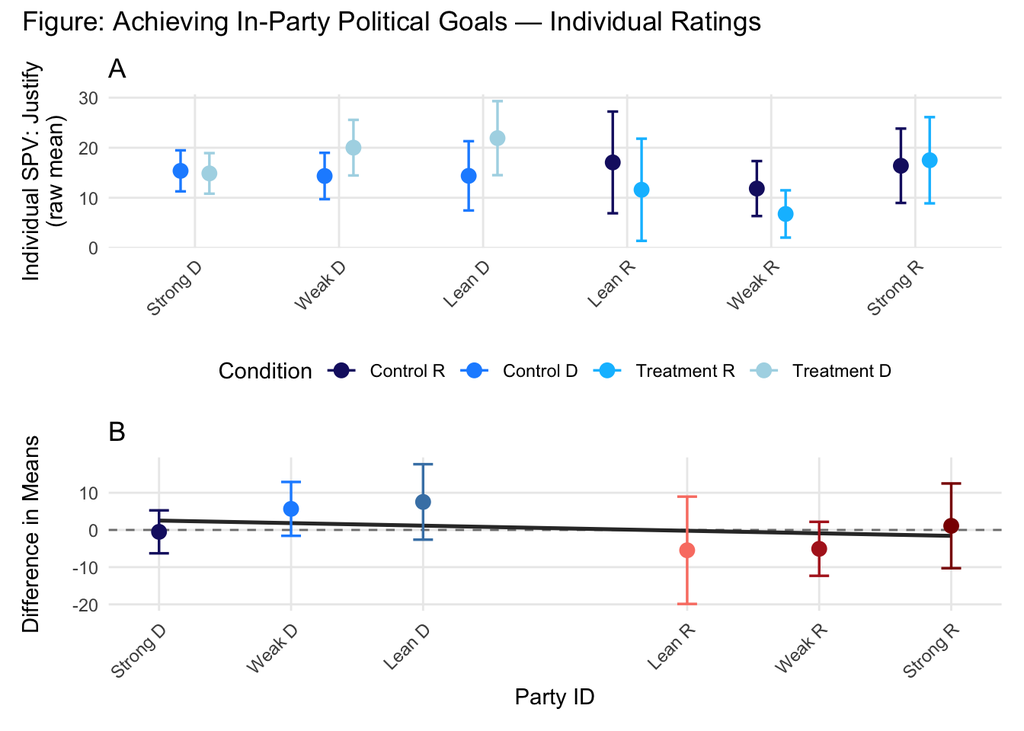

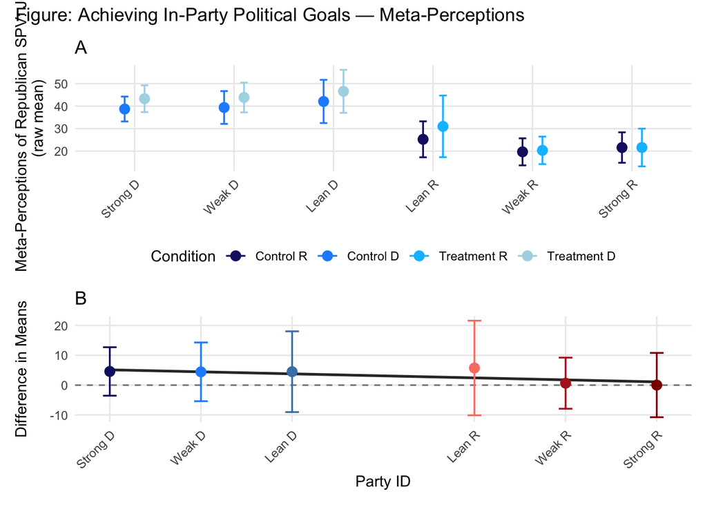

```r
justify_indiv_factor <- lm_robust(SPV_indiv_justify ~ condition_dummy * factor(party_numeric),
                                  data = data_clean, se_type = "HC2")
emm_justify_indiv_factor <- emmeans(justify_indiv_factor, ~ condition_dummy | party_numeric,
                                    vcov. = vcov(justify_indiv_factor))
contr_justify_indiv_factor_df <- confint(contrast(emm_justify_indiv_factor,
                                                  method = list("Treatment - Control" = c(-1, 1)),
                                                  by = "party_numeric")) |>
  as.data.frame() |>
  mutate(party_numeric = as.numeric(as.character(party_numeric)))

justify_meta_R_factor <- lm_robust(SPV_meta_justify ~ condition_dummy * factor(party_numeric),
                                   data = data_clean, se_type = "HC2")
emm_justify_meta_R_factor <- emmeans(justify_meta_R_factor, ~ condition_dummy | party_numeric,
                                     vcov. = vcov(justify_meta_R_factor))
contr_justify_meta_R_factor_df <- confint(contrast(emm_justify_meta_R_factor,
                                                   method = list("Treatment - Control" = c(-1, 1)),
                                                   by = "party_numeric")) |>
  as.data.frame() |>
  mutate(party_numeric = as.numeric(as.character(party_numeric)))

p_justify_indiv <- make_SPV_panels(
  "SPV_indiv_justify",
  contr_justify_indiv_partyaffil_df,
  contr_justify_indiv_factor_df,
  "Individual SPV: Justify\n(raw mean)",
  "Figure: Achieving In-Party Political Goals — Individual Ratings",
  color_A = c("Control R" = "midnightblue", "Treatment R" = "deepskyblue",
              "Control D" = "dodgerblue",    "Treatment D" = "lightblue"))

p_justify_meta_R <- make_SPV_panels(
  "SPV_meta_justify",
  contr_justify_meta_R_partyaffil_df,
  contr_justify_meta_R_factor_df,
  "Meta-Perceptions of Republican SPV: Justify\n(raw mean)",
  "Figure: Achieving In-Party Political Goals — Meta-Perceptions",
  color_A = c("Control R" = "midnightblue", "Treatment R" = "deepskyblue",
              "Control D" = "dodgerblue",    "Treatment D" = "lightblue"))
```

### Scenario: If the other party wins the next election

#### Models

```r
# 1.1: form models for:
# A: Individual SPV (Aggregated)
lm_predict_indiv <- lm_robust(SPV_indiv_predict ~ condition_dummy * PID_dummy * PID_bin,
                              data = data_clean, se_type = "HC2")
# B: Meta-Perceptions of Republican SPV
lm_predict_meta_R <- lm_robust(SPV_meta_predict ~ condition_dummy * PID_dummy * PID_bin,
                               data = data_clean, se_type = "HC2")
# C: Individual SPV (Reps only)
lm_R_predict <- lm_robust(spv_Rpredict ~ condition_dummy * PID_bin,
                          data = data_clean, se_type = "HC2")
# D: Individual SPV (Dems only)
lm_D_predict <- lm_robust(spv_Dpredict ~ condition_dummy * PID_bin,
                          data = data_clean, se_type = "HC2")
```

Individual SPV

| term | estimate | std.error | statistic | p.value | conf.low | conf.high | df | outcome |
| --- | --- | --- | --- | --- | --- | --- | --- | --- |
| (Intercept) | 8.684 | 2.738 | 3.171 | 0.002 | 3.309 | 14.060 | 774 | SPV_indiv_predict |
| condition_dummy | 17.457 | 5.768 | 3.027 | 0.003 | 6.135 | 28.780 | 774 | SPV_indiv_predict |
| PID_dummy | -10.176 | 4.263 | -2.387 | 0.017 | -18.544 | -1.808 | 774 | SPV_indiv_predict |
| PID_bin | 2.585 | 1.848 | 1.399 | 0.162 | -1.042 | 6.212 | 774 | SPV_indiv_predict |
| condition_dummy:PID_dummy | -19.921 | 7.012 | -2.841 | 0.005 | -33.686 | -6.155 | 774 | SPV_indiv_predict |
| condition_dummy:PID_bin | -8.557 | 3.462 | -2.471 | 0.014 | -15.353 | -1.760 | 774 | SPV_indiv_predict |
| PID_dummy:PID_bin | 5.563 | 3.183 | 1.748 | 0.081 | -0.684 | 11.811 | 774 | SPV_indiv_predict |
| condition_dummy:PID_dummy:PID_bin | 9.284 | 5.019 | 1.850 | 0.065 | -0.569 | 19.137 | 774 | SPV_indiv_predict |

Meta-Perceptions Republican SPV

| term | estimate | std.error | statistic | p.value | conf.low | conf.high | df | outcome |
| --- | --- | --- | --- | --- | --- | --- | --- | --- |
| (Intercept) | 39.627 | 5.498 | 7.207 | 0.000 | 28.834 | 50.420 | 775 | SPV_meta_predict |
| condition_dummy | 10.335 | 7.970 | 1.297 | 0.195 | -5.311 | 25.981 | 775 | SPV_meta_predict |
| PID_dummy | -33.162 | 6.271 | -5.288 | 0.000 | -45.472 | -20.851 | 775 | SPV_meta_predict |
| PID_bin | 2.282 | 3.347 | 0.682 | 0.496 | -4.289 | 8.852 | 775 | SPV_meta_predict |
| condition_dummy:PID_dummy | 4.300 | 10.272 | 0.419 | 0.676 | -15.864 | 24.464 | 775 | SPV_meta_predict |
| condition_dummy:PID_bin | -3.871 | 4.864 | -0.796 | 0.426 | -13.418 | 5.677 | 775 | SPV_meta_predict |
| PID_dummy:PID_bin | 5.689 | 4.083 | 1.393 | 0.164 | -2.327 | 13.705 | 775 | SPV_meta_predict |
| condition_dummy:PID_dummy:PID_bin | -4.508 | 6.656 | -0.677 | 0.498 | -17.574 | 8.559 | 775 | SPV_meta_predict |

Individual SPV (Republicans Only)

| term | estimate | std.error | statistic | p.value | conf.low | conf.high | df | outcome |
| --- | --- | --- | --- | --- | --- | --- | --- | --- |
| (Intercept) | -1.492 | 3.267 | -0.457 | 0.648 | -7.926 | 4.942 | 255 | spv_Rpredict |
| condition_dummy | -2.463 | 3.988 | -0.618 | 0.537 | -10.317 | 5.390 | 255 | spv_Rpredict |
| PID_bin | 8.148 | 2.591 | 3.145 | 0.002 | 3.045 | 13.251 | 255 | spv_Rpredict |
| condition_dummy:PID_bin | 0.728 | 3.634 | 0.200 | 0.841 | -6.429 | 7.884 | 255 | spv_Rpredict |

Individual SPV (Democrats Only)

| term | estimate | std.error | statistic | p.value | conf.low | conf.high | df | outcome |
| --- | --- | --- | --- | --- | --- | --- | --- | --- |
| (Intercept) | 8.684 | 2.738 | 3.171 | 0.002 | 3.305 | 14.064 | 519 | spv_Dpredict |
| condition_dummy | 17.457 | 5.768 | 3.027 | 0.003 | 6.126 | 28.789 | 519 | spv_Dpredict |
| PID_bin | 2.585 | 1.848 | 1.399 | 0.162 | -1.045 | 6.215 | 519 | spv_Dpredict |
| condition_dummy:PID_bin | -8.557 | 3.462 | -2.471 | 0.014 | -15.358 | -1.755 | 519 | spv_Dpredict |

#### Party ID (Dummy)

```r
# form emmeans and contrast matrices for Individual SPV (Aggregated)
emm_predict_indiv <- emmeans(lm_predict_indiv, ~ condition_dummy * PID_dummy,
                             vcov. = vcov(lm_predict_indiv))
emm_predict_indiv_df <- as.data.frame(confint(emm_predict_indiv)) %>%
  mutate(
    condition_dummy = factor(condition_dummy, levels = c(0, 1),
                             labels = c("Control", "Treatment")),
    PID_dummy = factor(PID_dummy, levels = c(0, 1),
                       labels = c("Democrat", "Republican")),
    group = interaction(condition_dummy, PID_dummy))
contr_predict_indiv <- contrast(emm_predict_indiv,
                                method = list(
                                  "Control D vs. Control R"     = c(-1,  0,  1,  0),
                                  "Control D vs. Treatment D"   = c(-1,  1,  0,  0),
                                  "Control R vs. Treatment R"   = c( 0,  0, -1,  1),
                                  "Treatment D vs. Treatment R" = c( 0, -1,  0,  1)))
contr_predict_indiv_df <- as.data.frame(confint(contr_predict_indiv))
contr_table_predict_indiv <- summary(contr_predict_indiv) |>
  as.data.frame() |>
  dplyr::select(contrast, estimate, SE, df, t.ratio, p.value)
```

| contrast | estimate | SE | df | t.ratio | p.value |
| --- | --- | --- | --- | --- | --- |
| Control D vs. Control R | -1.791972 | 2.244967 | 774 | -0.7982174 | 0.4249892 |
| Control D vs. Treatment D | 4.562643 | 2.103483 | 774 | 2.1690898 | 0.0303796 |
| Control R vs. Treatment R | -1.366805 | 2.655832 | 774 | -0.5146426 | 0.6069497 |
| Treatment D vs. Treatment R | -7.721419 | 2.537363 | 774 | -3.0430884 | 0.0024208 |

```r
# form emmeans and contrast matrices for Meta-Perceptions of Republican SPV
emm_predict_meta_R <- emmeans(lm_predict_meta_R, ~ condition_dummy * PID_dummy,
                              vcov. = vcov(lm_predict_meta_R))
emm_predict_meta_R_df <- as.data.frame(confint(emm_predict_meta_R)) %>%
  mutate(
    condition_dummy = factor(condition_dummy, levels = c(0, 1),
                             labels = c("Control", "Treatment")),
    PID_dummy = factor(PID_dummy, levels = c(0, 1),
                       labels = c("Democrat", "Republican")),
    group = interaction(condition_dummy, PID_dummy))
contr_predict_meta_R <- contrast(emm_predict_meta_R,
                                 method = list(
                                   "Control D vs. Control R"     = c(-1,  0,  1,  0),
                                   "Control D vs. Treatment D"   = c(-1,  1,  0,  0),
                                   "Control R vs. Treatment R"   = c( 0,  0, -1,  1),
                                   "Treatment D vs. Treatment R" = c( 0, -1,  0,  1)))
contr_predict_meta_R_df <- as.data.frame(confint(contr_predict_meta_R))
contr_table_predict_meta_R <- summary(contr_predict_meta_R) |>
  as.data.frame() |>
  dplyr::select(contrast, estimate, SE, df, t.ratio, p.value)
```

| contrast | estimate | SE | df | t.ratio | p.value |
| --- | --- | --- | --- | --- | --- |
| Control D vs. Control R | -24.588731 | 2.767836 | 775 | -8.8837392 | 0.0000000 |
| Control D vs. Treatment D | 4.501966 | 3.006415 | 775 | 1.4974534 | 0.1346825 |
| Control R vs. Treatment R | 2.008337 | 3.010590 | 775 | 0.6670909 | 0.5049127 |
| Treatment D vs. Treatment R | -27.082360 | 3.231295 | 775 | -8.3812707 | 0.0000000 |

#### Party ID (7-pt)

```r
# form emmeans and contrast matrices for Individual SPV (Aggregated)
predict_indiv_partyaffil <- lm_robust(SPV_indiv_predict ~ condition_dummy * party_numeric, data = data_clean, se_type = "HC2")
emm_predict_indiv_partyaffil<- emmeans(predict_indiv_partyaffil, ~ condition_dummy * party_numeric,
                                       at = list(party_numeric = c(1, 2, 3, 5, 6, 7)),
                                       vcov. = vcov(predict_indiv_partyaffil))
contr_predict_indiv_partyaffil<- contrast(emm_predict_indiv_partyaffil,
                                          method = list("Treatment - Control" = c(-1, 1)),
                                          by = "party_numeric")
contr_predict_indiv_partyaffil_df <- confint(contr_predict_indiv_partyaffil) |>
  as.data.frame() |>
  mutate(
    party_label = factor(party_numeric, levels = c(1, 2, 3, 5, 6, 7),
                         labels = c("Strong D","Weak D","Lean D","Lean R","Weak R","Strong R")),
    model = "Individual Ratings")
```

| contrast | party_numeric | estimate | SE | df | lower.CL | upper.CL | party_label | model |
| --- | --- | --- | --- | --- | --- | --- | --- | --- |
| Treatment - Control | 1 | 4.6637554 | 2.346620 | 782 | 0.0573361 | 9.270175 | Strong D | Individual Ratings |
| Treatment - Control | 2 | 3.6530960 | 1.905508 | 782 | -0.0874206 | 7.393613 | Weak D | Individual Ratings |
| Treatment - Control | 3 | 2.6424366 | 1.660807 | 782 | -0.6177305 | 5.902604 | Lean D | Individual Ratings |
| Treatment - Control | 5 | 0.6211177 | 2.005456 | 782 | -3.3155961 | 4.557832 | Lean R | Individual Ratings |
| Treatment - Control | 6 | -0.3895417 | 2.481554 | 782 | -5.2608370 | 4.481753 | Weak R | Individual Ratings |
| Treatment - Control | 7 | -1.4002012 | 3.049155 | 782 | -7.3856985 | 4.585296 | Strong R | Individual Ratings |

```r
# form emmeans and contrast matrices for Meta-Perceptions of Republican SPV
predict_meta_R_partyaffil <- lm_robust(SPV_meta_predict ~ condition_dummy * party_numeric, data = data_clean, se_type = "HC2")
emm_predict_meta_R_partyaffil<- emmeans(predict_meta_R_partyaffil, ~ condition_dummy * party_numeric,
                                        at = list(party_numeric = c(1, 2, 3, 5, 6, 7)),
                                        vcov. = vcov(predict_meta_R_partyaffil))
contr_predict_meta_R_partyaffil<- contrast(emm_predict_meta_R_partyaffil,
                                           method = list("Treatment - Control" = c(-1, 1)),
                                           by = "party_numeric")
contr_predict_meta_R_partyaffil_df <- confint(contr_predict_meta_R_partyaffil) |>
  as.data.frame() |>
  mutate(
    party_label = factor(party_numeric, levels = c(1, 2, 3, 5, 6, 7),
                         labels = c("Strong D","Weak D","Lean D","Lean R","Weak R","Strong R")),
    model = "Meta-Perceptions of Republicans' Ratings")
```

| contrast | party_numeric | estimate | SE | df | lower.CL | upper.CL | party_label | model |
| --- | --- | --- | --- | --- | --- | --- | --- | --- |
| Treatment - Control | 1 | 4.927844 | 3.420618 | 783 | -1.7868235 | 11.642511 | Strong D | Meta-Perceptions of Republicans’ Ratings |
| Treatment - Control | 2 | 4.620863 | 2.771708 | 783 | -0.8199958 | 10.061721 | Weak D | Meta-Perceptions of Republicans’ Ratings |
| Treatment - Control | 3 | 4.313882 | 2.304094 | 783 | -0.2090517 | 8.836815 | Lean D | Meta-Perceptions of Republicans’ Ratings |
| Treatment - Control | 5 | 3.699919 | 2.344367 | 783 | -0.9020688 | 8.301908 | Lean R | Meta-Perceptions of Republicans’ Ratings |
| Treatment - Control | 6 | 3.392938 | 2.838446 | 783 | -2.1789269 | 8.964804 | Weak R | Meta-Perceptions of Republicans’ Ratings |
| Treatment - Control | 7 | 3.085957 | 3.501749 | 783 | -3.7879695 | 9.959884 | Strong R | Meta-Perceptions of Republicans’ Ratings |

#### Party ID (7-pt) + Partisan Self-Concept

```r
lm_predict_indiv_R_7 <- lm_robust(SPV_indiv_predict ~ condition_dummy * party_numeric * PID_bin,
                                  data = data_clean, se_type = "HC2")
emm_predict_indiv_R_7<- emmeans(lm_predict_indiv_R_7, ~ condition_dummy | party_numeric,
                                at = list(party_numeric = c(1, 2, 3, 5, 6, 7)),
                                vcov. = vcov(lm_predict_indiv_R_7))
contr_predict_indiv_R_7<- contrast(emm_predict_indiv_R_7,
                                   method = list("Treatment - Control" = c(-1, 1)),
                                   by = "party_numeric")
contr_predict_indiv_R_7_df <- as.data.frame(confint(contr_predict_indiv_R_7))
contr_table_predict_indiv_R_7_df <- summary(contr_predict_indiv_R_7) |>
  as.data.frame() |>
  dplyr::select(contrast, party_numeric, estimate, SE, df, t.ratio, p.value) |>
  mutate(party_label = factor(party_numeric, levels = c(1, 2, 3, 5, 6, 7),
                              labels = c("Strong D","Weak D","Lean D","Lean R","Weak R","Strong R")))
```

| contrast | party_numeric | estimate | SE | df | t.ratio | p.value | party_label |
| --- | --- | --- | --- | --- | --- | --- | --- |
| Treatment - Control | 1 | 6.5198746 | 2.548158 | 774 | 2.5586618 | 0.0106968 | Strong D |
| Treatment - Control | 2 | 4.9436022 | 2.063012 | 774 | 2.3963035 | 0.0167978 | Weak D |
| Treatment - Control | 3 | 3.3673299 | 1.743837 | 774 | 1.9309884 | 0.0538494 | Lean D |
| Treatment - Control | 5 | 0.2147852 | 1.917551 | 774 | 0.1120101 | 0.9108444 | Lean R |
| Treatment - Control | 6 | -1.3614872 | 2.351188 | 774 | -0.5790636 | 0.5627147 | Weak R |
| Treatment - Control | 7 | -2.9377596 | 2.898484 | 774 | -1.0135504 | 0.3111140 | Strong R |

```r
lm_predict_meta_R_7 <- lm_robust(SPV_meta_predict ~ condition_dummy * party_numeric * PID_bin,
                                 data = data_clean, se_type = "HC2")
emm_predict_meta_R_7<- emmeans(lm_predict_meta_R_7, ~ condition_dummy | party_numeric,
                               at = list(party_numeric = c(1, 2, 3, 5, 6, 7)),
                               vcov. = vcov(lm_predict_meta_R_7))
contr_predict_meta_R_7<- contrast(emm_predict_meta_R_7,
                                  method = list("Treatment - Control" = c(-1, 1)),
                                  by = "party_numeric")
contr_predict_meta_R_7_df <- as.data.frame(confint(contr_predict_meta_R_7))
contr_table_predict_meta_R_7_df <- summary(contr_predict_meta_R_7) |>
  as.data.frame() |>
  dplyr::select(contrast, party_numeric, estimate, SE, df, t.ratio, p.value) |>
  mutate(party_label = factor(party_numeric, levels = c(1, 2, 3, 5, 6, 7),
                              labels = c("Strong D","Weak D","Lean D","Lean R","Weak R","Strong R")))
```

| contrast | party_numeric | estimate | SE | df | t.ratio | p.value | party_label |
| --- | --- | --- | --- | --- | --- | --- | --- |
| Treatment - Control | 1 | 4.468594 | 3.605082 | 775 | 1.2395262 | 0.2155259 | Strong D |
| Treatment - Control | 2 | 4.297298 | 2.898957 | 775 | 1.4823598 | 0.1386511 | Weak D |
| Treatment - Control | 3 | 4.126001 | 2.362126 | 775 | 1.7467323 | 0.0810799 | Lean D |
| Treatment - Control | 5 | 3.783408 | 2.288245 | 775 | 1.6534103 | 0.0986524 | Lean R |
| Treatment - Control | 6 | 3.612111 | 2.777914 | 775 | 1.3002961 | 0.1938861 | Weak R |
| Treatment - Control | 7 | 3.440814 | 3.459177 | 775 | 0.9946917 | 0.3201967 | Strong R |

#### Factor models for panel plots

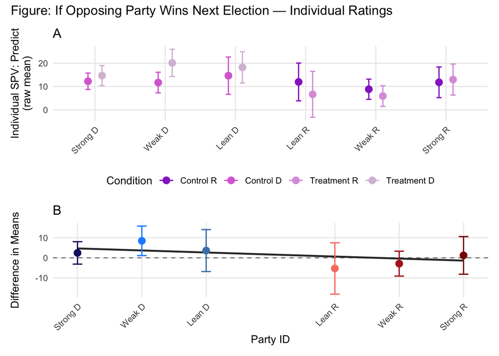

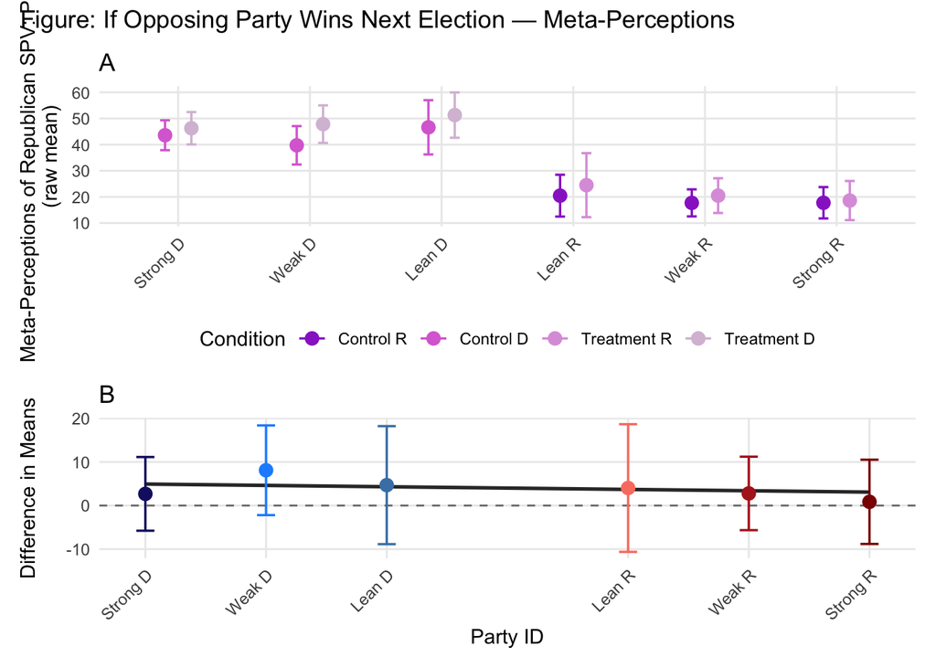

```r
predict_indiv_factor <- lm_robust(SPV_indiv_predict ~ condition_dummy * factor(party_numeric),
                                  data = data_clean, se_type = "HC2")
emm_predict_indiv_factor <- emmeans(predict_indiv_factor, ~ condition_dummy | party_numeric,
                                    vcov. = vcov(predict_indiv_factor))
contr_predict_indiv_factor_df <- confint(contrast(emm_predict_indiv_factor,
                                                  method = list("Treatment - Control" = c(-1, 1)),
                                                  by = "party_numeric")) |>
  as.data.frame() |>
  mutate(party_numeric = as.numeric(as.character(party_numeric)))

predict_meta_R_factor <- lm_robust(SPV_meta_predict ~ condition_dummy * factor(party_numeric),
                                   data = data_clean, se_type = "HC2")
emm_predict_meta_R_factor <- emmeans(predict_meta_R_factor, ~ condition_dummy | party_numeric,
                                     vcov. = vcov(predict_meta_R_factor))
contr_predict_meta_R_factor_df <- confint(contrast(emm_predict_meta_R_factor,
                                                   method = list("Treatment - Control" = c(-1, 1)),
                                                   by = "party_numeric")) |>
  as.data.frame() |>
  mutate(party_numeric = as.numeric(as.character(party_numeric)))

p_predict_indiv <- make_SPV_panels(
  "SPV_indiv_predict",
  contr_predict_indiv_partyaffil_df,
  contr_predict_indiv_factor_df,
  "Individual SPV: Predict\n(raw mean)",
  "Figure: If Opposing Party Wins Next Election — Individual Ratings",
  color_A = c("Control R" = "darkorchid", "Treatment R" = "plum",
              "Control D" = "orchid",      "Treatment D" = "thistle"))

p_predict_meta_R <- make_SPV_panels(
  "SPV_meta_predict",
  contr_predict_meta_R_partyaffil_df,
  contr_predict_meta_R_factor_df,
  "Meta-Perceptions of Republican SPV: Predict\n(raw mean)",
  "Figure: If Opposing Party Wins Next Election — Meta-Perceptions",
  color_A = c("Control R" = "darkorchid", "Treatment R" = "plum",
              "Control D" = "orchid",      "Treatment D" = "thistle"))
```

## Binned Scenarios SPV

Secondarily to the scenario-specific models, I plan to combine the four scenario-specific questions and the two broad-based questions into two, distinct averages measuring individual and meta-perceptions of Republicans’ SPV. I will then apply the same Ordinary Least Squares (OLS) linear regression models with heteroskedasticity-robust standard errors to these aggregated variables, including the exact same covariates as for each of the six individual questions regarding SPV scenarios.

*I deviated from the pre-analysis plan by removing the additional specified covariates from each model, as this simplifies the ability to draw conclusions about the average treatment effect. The only covariates included are PID_dummy, which represents the dichotomous effect of being a Democrat versus a Republican, and PID_bin, the grouped version of partisan self-concept.*

### Create four baseline models

```r
lm_indiv_scenario <- lm_robust(SPV_indiv_scenario ~ condition_dummy, data = data_clean)
lm_indiv_broad <- lm_robust(SPV_indiv_broad ~ condition_dummy, data = data_clean)
lm_meta_R_scenario <- lm_robust(SPV_meta_scenario ~ condition_dummy, data = data_clean)
lm_meta_R_broad <- lm_robust(SPV_meta_broad ~ condition_dummy, data = data_clean)
```

| term | estimate | std.error | statistic | p.value | conf.low | conf.high | df | outcome |
| --- | --- | --- | --- | --- | --- | --- | --- | --- |
| (Intercept) | 25.532 | 1.029 | 24.801 | 0.00 | 23.511 | 27.553 | 780 | SPV_indiv_scenario |
| condition_dummy | 2.373 | 1.525 | 1.556 | 0.12 | -0.621 | 5.367 | 780 | SPV_indiv_scenario |

| term | estimate | std.error | statistic | p.value | conf.low | conf.high | df | outcome |
| --- | --- | --- | --- | --- | --- | --- | --- | --- |
| (Intercept) | 13.268 | 1.089 | 12.183 | 0.000 | 11.130 | 15.406 | 784 | SPV_indiv_broad |
| condition_dummy | 2.017 | 1.619 | 1.246 | 0.213 | -1.161 | 5.195 | 784 | SPV_indiv_broad |

| term | estimate | std.error | statistic | p.value | conf.low | conf.high | df | outcome |
| --- | --- | --- | --- | --- | --- | --- | --- | --- |
| (Intercept) | 39.515 | 1.264 | 31.266 | 0.000 | 37.034 | 41.996 | 781 | SPV_meta_scenario |
| condition_dummy | 5.646 | 1.906 | 2.961 | 0.003 | 1.903 | 9.388 | 781 | SPV_meta_scenario |

| term | estimate | std.error | statistic | p.value | conf.low | conf.high | df | outcome |
| --- | --- | --- | --- | --- | --- | --- | --- | --- |
| (Intercept) | 33.361 | 1.496 | 22.297 | 0.000 | 30.424 | 36.298 | 785 | SPV_meta_broad |
| condition_dummy | 5.446 | 2.242 | 2.429 | 0.015 | 1.045 | 9.847 | 785 | SPV_meta_broad |

### INDIV_SCENARIO

```r
# A: bivariate
lm_indiv_1 <- lm(SPV_indiv_scenario ~ condition_dummy, data = data_clean)
# B: multivariate
lm_indiv_1_cov <- lm(SPV_indiv_scenario ~ condition_dummy * PID_dummy * PID_bin,
                     data = data_clean)
```

| term | estimate | std.error | statistic | p.value |
| --- | --- | --- | --- | --- |
| (Intercept) | 25.532 | 1.074 | 23.779 | 0.00 |
| condition_dummy | 2.373 | 1.524 | 1.557 | 0.12 |

| term | estimate | std.error | statistic | p.value |
| --- | --- | --- | --- | --- |
| (Intercept) | 24.096 | 3.307 | 7.285 | 0.000 |
| condition_dummy | 10.277 | 4.731 | 2.172 | 0.030 |
| PID_dummy | -19.442 | 5.549 | -3.504 | 0.000 |
| PID_bin | 1.379 | 2.017 | 0.683 | 0.495 |
| condition_dummy:PID_dummy | -3.594 | 8.072 | -0.445 | 0.656 |
| condition_dummy:PID_bin | -4.166 | 2.861 | -1.457 | 0.146 |
| PID_dummy:PID_bin | 11.729 | 3.407 | 3.443 | 0.001 |
| condition_dummy:PID_dummy:PID_bin | -0.921 | 5.019 | -0.184 | 0.854 |

### INDIV_BROAD

```r
# A: bivariate
lm_indiv_2 <- lm(SPV_indiv_broad ~ condition_dummy, data = data_clean)
# B: multivariate
lm_indiv_2_cov <- lm(SPV_indiv_broad ~ condition_dummy * PID_dummy * PID_bin,
                     data = data_clean)
```

| term | estimate | std.error | statistic | p.value |
| --- | --- | --- | --- | --- |
| (Intercept) | 13.268 | 1.141 | 11.626 | 0.000 |
| condition_dummy | 2.017 | 1.618 | 1.246 | 0.213 |

| term | estimate | std.error | statistic | p.value |
| --- | --- | --- | --- | --- |
| (Intercept) | 11.304 | 3.612 | 3.129 | 0.002 |
| condition_dummy | 13.043 | 5.120 | 2.547 | 0.011 |
| PID_dummy | -10.285 | 5.997 | -1.715 | 0.087 |
| PID_bin | 1.547 | 2.196 | 0.704 | 0.481 |
| condition_dummy:PID_dummy | -16.827 | 8.697 | -1.935 | 0.053 |
| condition_dummy:PID_bin | -6.082 | 3.090 | -1.968 | 0.049 |
| PID_dummy:PID_bin | 6.296 | 3.665 | 1.718 | 0.086 |
| condition_dummy:PID_dummy:PID_bin | 7.303 | 5.395 | 1.354 | 0.176 |

### META_R_SCENARIO

```r
# A: bivariate
lm_meta_R_1 <- lm(SPV_meta_scenario ~ condition_dummy, data = data_clean)
# B: multivariate
lm_meta_R_1_cov <- lm(SPV_meta_scenario ~ condition_dummy * PID_dummy * PID_bin,
                      data = data_clean)
```

| term | estimate | std.error | statistic | p.value |
| --- | --- | --- | --- | --- |
| (Intercept) | 39.515 | 1.339 | 29.519 | 0.000 |
| condition_dummy | 5.646 | 1.904 | 2.965 | 0.003 |

| term | estimate | std.error | statistic | p.value |
| --- | --- | --- | --- | --- |
| (Intercept) | 42.586 | 4.158 | 10.243 | 0.000 |
| condition_dummy | 14.340 | 5.947 | 2.411 | 0.016 |
| PID_dummy | -22.266 | 6.972 | -3.194 | 0.001 |
| PID_bin | -0.156 | 2.536 | -0.061 | 0.951 |
| condition_dummy:PID_dummy | 7.954 | 10.150 | 0.784 | 0.433 |
| condition_dummy:PID_bin | -5.355 | 3.594 | -1.490 | 0.137 |
| PID_dummy:PID_bin | 9.710 | 4.271 | 2.274 | 0.023 |
| condition_dummy:PID_dummy:PID_bin | -7.892 | 6.317 | -1.249 | 0.212 |

### META_R_BROAD

```r
# A: bivariate
lm_meta_R_2 <- lm(SPV_meta_broad ~ condition_dummy, data = data_clean)
# B: multivariate
lm_meta_R_2_cov <- lm(SPV_meta_broad ~ condition_dummy * PID_dummy * PID_bin,
                     data = data_clean)
```

| term | estimate | std.error | statistic | p.value |
| --- | --- | --- | --- | --- |
| (Intercept) | 33.361 | 1.579 | 21.126 | 0.000 |
| condition_dummy | 5.446 | 2.240 | 2.431 | 0.015 |

| term | estimate | std.error | statistic | p.value |
| --- | --- | --- | --- | --- |
| (Intercept) | 39.973 | 4.761 | 8.396 | 0.000 |
| condition_dummy | 7.090 | 6.748 | 1.051 | 0.294 |
| PID_dummy | -30.992 | 7.917 | -3.915 | 0.000 |
| PID_bin | 0.859 | 2.898 | 0.297 | 0.767 |
| condition_dummy:PID_dummy | 7.535 | 11.485 | 0.656 | 0.512 |
| condition_dummy:PID_bin | -1.731 | 4.078 | -0.425 | 0.671 |
| PID_dummy:PID_bin | 6.548 | 4.840 | 1.353 | 0.177 |
| condition_dummy:PID_dummy:PID_bin | -7.331 | 7.135 | -1.027 | 0.305 |

## Independent-Samples T-Tests

Lastly, in line with earlier work by Mernyk et al. (2022), I plan to perform three independent-samples t-tests comparing Republican to Democratic participants regarding their predicted and actual levels of support for political violence. The first t-test will compare Republicans’ reported individual SPV to Democrats’ meta-perceptions of Republicans’ SPV, while the second t-test will compare Republicans’ individual SPV to their own meta-perceptions of co-partisans’ SPV. The third t-test will compare meta-perceptions of Republicans’ SPV between Republicans and Democrats. I will use the standard p<.05 criteria in our two-tailed T-test to determine whether significant differences exist between individual support of partisan violence and meta-perceptions of Republicans’ support for partisan violence. For all t-tests, I plan to calculate the effect size as Cohen’s d.

```r
# 8. outparty metaperceptions
# 8.1: actual views of R vs. how D think R will respond
t.test(na.omit((data_clean %>% filter(party_numeric >= 4))$SPV_individual),
       na.omit((data_clean %>% filter(party_numeric <= 3))$SPV_meta_outgroup))
```

```
##
##  Welch Two Sample t-test
##
## data:  na.omit((data_clean %>% filter(party_numeric >= 4))$SPV_individual) and na.omit((data_clean %>% filter(party_numeric <= 3))$SPV_meta_outgroup)
## t = -14.191, df = 628.49, p-value < 2.2e-16
## alternative hypothesis: true difference in means is not equal to 0
## 95 percent confidence interval:
##  -28.62956 -21.66938
## sample estimates:
## mean of x mean of y
##  19.62387  44.77333
```

```r
# 8.2: effect size
cohen.d(na.omit((data_clean %>% filter(party_numeric >= 4))$SPV_individual),
       na.omit((data_clean %>% filter(party_numeric <= 3))$SPV_meta_outgroup))
```

```
##
## Cohen's d
##
## d estimate: -0.996642 (large)
## 95 percent confidence interval:
##      lower      upper
## -1.1540616 -0.8392224
```

```r
# 9. inparty metaperceptions
# 9.1: actual views of R vs. how R think R will respond
t.test(na.omit((data_clean %>% filter(party_numeric >= 4))$SPV_individual),
       na.omit((data_clean %>% filter(party_numeric >= 4))$SPV_meta_ingroup))
```

```
##
##  Welch Two Sample t-test
##
## data:  na.omit((data_clean %>% filter(party_numeric >= 4))$SPV_individual) and na.omit((data_clean %>% filter(party_numeric >= 4))$SPV_meta_ingroup)
## t = -6.0073, df = 515, p-value = 3.568e-09
## alternative hypothesis: true difference in means is not equal to 0
## 95 percent confidence interval:
##  -14.997798  -7.605754
## sample estimates:
## mean of x mean of y
##  19.62387  30.92564
```

```r
# 9.2: effect size
cohen.d(na.omit((data_clean %>% filter(party_numeric >= 4))$SPV_individual),
        na.omit((data_clean %>% filter(party_numeric >= 4))$SPV_meta_ingroup))
```

```
##
## Cohen's d
##
## d estimate: -0.5283701 (medium)
## 95 percent confidence interval:
##      lower      upper
## -0.7041666 -0.3525736
```

```r
# 10. are democrats' inaccuracies different from republicans' inaccuracies?
# 10.1: how D think R will respond vs. how R think R will respond
t.test(na.omit((data_clean %>% filter(party_numeric <= 3))$SPV_meta_outgroup),
       na.omit((data_clean %>% filter(party_numeric >= 4))$SPV_meta_ingroup))
```

```
##
##  Welch Two Sample t-test
##
## data:  na.omit((data_clean %>% filter(party_numeric <= 3))$SPV_meta_outgroup) and na.omit((data_clean %>% filter(party_numeric >= 4))$SPV_meta_ingroup)
## t = 7.7772, df = 629.73, p-value = 3.04e-14
## alternative hypothesis: true difference in means is not equal to 0
## 95 percent confidence interval:
##  10.35117 17.34422
## sample estimates:
## mean of x mean of y
##  44.77333  30.92564
```

```r
# 10.2: effect size
cohen.d(na.omit((data_clean %>% filter(party_numeric <= 3))$SPV_meta_outgroup),
        na.omit((data_clean %>% filter(party_numeric >= 4))$SPV_meta_ingroup))
```

```
##
## Cohen's d
##
## d estimate: 0.547227 (medium)
## 95 percent confidence interval:
##     lower     upper
## 0.3959149 0.6985390
```